# RBN exploration

Carlos Blanco

```r
library(dplyr)
library(tidyr)
library(ggplot2)
library(purrr)
library(stringr)
library(data.table)
library(EnsDb.Mmusculus.v79)
library(EDASeq)
library(org.Mm.eg.db)
library(clusterProfiler)
library(enrichplot)
library(RColorConesa)
```

# 1 Per gene structural categories counts, total counts, median length and median number of exons

First, obtain a per gene classification file for each sample. In these files, each row will be a gene, and the columns will be the counts of reads for each structural category, the total of the read counts, the median of the lengths of each transcript model associated with that gene, and the median number of exons of each transcript model associated with that gene.

```r
# Classifications from SQANTI3 filter
files <- list.files(path = "/home/carblan/Documents/R_files/TFM/filtered_classifications", pattern = "^B", full.names = TRUE)

process_file <- function(file) {
  data <- read.delim(file, stringsAsFactors = FALSE)

  data_filtered <- data %>%
    filter(!(grepl("SIRV", chrom)) & !(filter_result == "Artifact") & !(structural_category %in% c("intergenic", "antisense", "fusion", "genic_intron")))

  inter_df <- data_filtered %>%
    select(isoform, chrom, associated_gene, structural_category, FL, length, exons) %>%
    arrange(associated_gene)  # Ordenar por associated_gene

  final_df <- inter_df %>%
    group_by(associated_gene, chrom) %>%
    summarise(median_length = median(length),
            median_exons = median(exons),
            full_splice_match_counts = sum(FL[structural_category == "full-splice_match"]),
            incomplete_splice_match_counts = sum(FL[structural_category == "incomplete-splice_match"]),
            novel_in_catalog_counts = sum(FL[structural_category == "novel_in_catalog"]),
            novel_not_in_catalog_counts = sum(FL[structural_category == "novel_not_in_catalog"]),
            genic_counts = sum(FL[structural_category == "genic"]),
            total_counts = sum(FL))

  sample_name <- sub("_.*", "", basename(file))
  output_name <- paste0(sample_name, "_per_gene_filtered_classification.txt")
  write.table(final_df, file = paste0("/home/carblan/Documents/R_files/TFM/filtered_per_gene_classifications/", output_name), sep = "\t", row.names = FALSE)
}

for (file in files) {
  process_file(file)
}
```

# 2 Per gene noisy reads ratio difference, average length and average number of exons (all samples intersection)

Once we have the per gene classifications with the counts, median length and median number of exons, we will calculate the noisy reads ratio difference per gene, alongside its length and number of exons. For this we first filter the genes that have at least 10 reads assigned as FSM in every sample, and also appear in every sample (to avoid genes that are underrepresented) Then, we obtain the ratio for each structural category of each gene, then the mean of the ratio of each structural category for the samples in the young group of mice and the samples in the old group of mice, independently. Then, the noisy reads ratio (NIC+NNC/NIC+NNC+FSM) is calculated for each gene of each age group and the difference (old - young) is obtained.

For the length and number of exons of the gene, we get the median length and median number of exons of each gene for each sample and compute the average for each age group. Then, from that average for each age group, a second average is calculated to obtain the final length and number of exons per gene.

```r
files <- list.files(path = "/home/carblan/Documents/R_files/TFM/filtered_per_gene_classifications",
                    full.names = TRUE)
filtered_data <- list()

for (file in files) {
  data <- read.table(file, header=TRUE, stringsAsFactors=FALSE)

  data <- data[data$full_splice_match_counts >= 10,]

  filtered_data[[file]] <- data
}

associated_genes <- Reduce(intersect, lapply(filtered_data, function(x) x$associated_gene))

dir <- "/home/carblan/Documents/R_files/TFM/FSM>=10_intersection_filtered_genes"
if (!dir.exists(dir)) {
  dir.create(dir)
}

for (file in files) {
  data <- filtered_data[[file]]
  data <- data[data$associated_gene %in% associated_genes,]

  write.table(data, file.path(dir, basename(file)), sep="\t", row.names=FALSE)
}

files <- list.files(path = "/home/carblan/Documents/R_files/TFM/FSM>=10_intersection_filtered_genes", pattern=".txt", full.names = TRUE)

output_dir <- "/home/carblan/Documents/R_files/TFM/FSM>=10_intersection_filtered_genes/per_gene_structural_categories_ratios"
if (!dir.exists(output_dir)) {
  dir.create(output_dir, recursive = TRUE)
}

for (file in files) {
  data <- read.table(file, header=TRUE, stringsAsFactors=FALSE)

  categories <- colnames(data)[5:ncol(data)]
  for (category in categories) {
    data[[category]] <- data[[category]] / data$total_counts
  }

  output_file <- file.path(output_dir, basename(file))
  write.table(data, output_file, sep="\t", quote=FALSE, row.names=FALSE)
}

input_dir <- "/home/carblan/Documents/R_files/TFM/FSM>=10_intersection_filtered_genes/per_gene_structural_categories_ratios"

files <- list.files(path = input_dir, pattern=".txt", full.names = TRUE)

young_files <- files[str_detect(basename(files), "^B3[1-5]")]
old_files <- files[str_detect(basename(files), "^B15[1-4]")]

calculate_mean_ratios <- function(files) {
  data <- map_dfr(files, ~read.table(.x, header=TRUE, stringsAsFactors=FALSE))

  data_mean <- data %>%
    group_by(associated_gene, chrom) %>%
    summarise(across(starts_with("median_length"), mean),
            across(starts_with("median_exons"), mean),
            across(starts_with("full"), mean),
            across(starts_with("incomplete"), mean),
            across(starts_with("novel_not"), mean),
            across(starts_with("novel_in"), mean),
            across(starts_with("genic"), mean),
            total_counts = mean(total_counts),
            .groups = "drop") %>%
    arrange(associated_gene)

  return(data_mean)
}

young_mean_ratios <- calculate_mean_ratios(young_files)

old_mean_ratios <- calculate_mean_ratios(old_files)

output_dir <- "/home/carblan/Documents/R_files/TFM/FSM>=10_intersection_filtered_genes/age_groups_per_gene_categories_mean_ratios"
if (!dir.exists(output_dir)) {
  dir.create(output_dir, recursive = TRUE)
}

write.table(young_mean_ratios, file.path(output_dir, "young_mean_ratios.txt"), sep="\t", quote=FALSE, row.names=FALSE)
write.table(old_mean_ratios, file.path(output_dir, "old_mean_ratios.txt"), sep="\t", quote=FALSE, row.names=FALSE)

input_dir <- "/home/carblan/Documents/R_files/TFM/FSM>=10_intersection_filtered_genes/age_groups_per_gene_categories_mean_ratios"

young_mean_ratios <- read.table(file.path(input_dir, "young_mean_ratios.txt"), header=TRUE, stringsAsFactors=FALSE)
old_mean_ratios <- read.table(file.path(input_dir, "old_mean_ratios.txt"), header=TRUE, stringsAsFactors=FALSE)

calculate_noisy_reads_ratios <- function(data) {
  noisy_reads_ratio <- (data$novel_in_catalog_counts + data$novel_not_in_catalog_counts) / (data$full_splice_match_counts + data$novel_in_catalog_counts + data$novel_not_in_catalog_counts)

  noisy_reads_ratios <- data.frame(
    associated_gene = data$associated_gene,
    chrom = data$chrom,
    average_length = data$median_length,
    average_exons = data$median_exons,
    noisy_reads_ratio = noisy_reads_ratio
  )

  return(noisy_reads_ratios)
}

young_noisy_reads_ratios <- calculate_noisy_reads_ratios(young_mean_ratios)
old_noisy_reads_ratios <- calculate_noisy_reads_ratios(old_mean_ratios)

output_dir <- "/home/carblan/Documents/R_files/TFM/FSM>=10_intersection_filtered_genes/per_gene_noisy_reads_ratio"
if (!dir.exists(output_dir)) {
  dir.create(output_dir)
}

write.table(young_noisy_reads_ratios, file.path(output_dir, "young_noisy_reads_ratios.txt"), sep="\t", quote=FALSE, row.names=FALSE)
write.table(old_noisy_reads_ratios, file.path(output_dir, "old_noisy_reads_ratios.txt"), sep="\t", quote=FALSE, row.names=FALSE)

input_dir <- "/home/carblan/Documents/R_files/TFM/FSM>=10_intersection_filtered_genes/per_gene_noisy_reads_ratio"

young_noisy_reads_ratios <- read.table(file.path(input_dir, "young_noisy_reads_ratios.txt"), header=TRUE, stringsAsFactors=FALSE)
old_noisy_reads_ratios <- read.table(file.path(input_dir, "old_noisy_reads_ratios.txt"), header=TRUE, stringsAsFactors=FALSE)

calculate_difference <- function(young_data, old_data) {
  combined_data <- merge(old_data, young_data, by = "associated_gene", suffixes = c("_old", "_young"))

  noisy_reads_ratio_diff <- combined_data$noisy_reads_ratio_old - combined_data$noisy_reads_ratio_young

  # Calcular la media de average_length y average_exons para cada associated_gene
  media_average_length <- rowMeans(combined_data[, c("average_length_old", "average_length_young")], na.rm = TRUE)
  media_average_exons <- rowMeans(combined_data[, c("average_exons_old", "average_exons_young")], na.rm = TRUE)

  noisy_reads_ratio_difference <- data.frame(
    associated_gene = combined_data$associated_gene,
    chrom = combined_data$chrom_old,
    average_length = media_average_length,
    average_exons = media_average_exons,
    noisy_reads_ratio_diff = noisy_reads_ratio_diff
  )

  return(noisy_reads_ratio_difference)
}

noisy_reads_ratio_difference <- calculate_difference(young_noisy_reads_ratios, old_noisy_reads_ratios)

output_dir <- "/home/carblan/Documents/R_files/TFM/FSM>=10_intersection_filtered_genes/per_gene_noisy_reads_ratio"
if (!dir.exists(output_dir)) {
  dir.create(output_dir)
}

write.table(noisy_reads_ratio_difference, file.path(output_dir, "noisy_reads_ratio_difference_per_gene.txt"), sep="\t", quote=FALSE, row.names=FALSE)
```

## 2.1 Per gene noisy reads ratio difference distribution

```r
# Function
RBN_histogram <- function(data) {
  # Filtramos los valores diferentes de 0
  data_filtrado <- data[complete.cases(data) & data$noisy_reads_ratio_diff != 0, ]

  # Calculamos el porcentaje de genes por encima y por debajo de 0
  genes_above_0 <- sum(data_filtrado[, "noisy_reads_ratio_diff"] > 0)
  genes_below_0 <- sum(data_filtrado[, "noisy_reads_ratio_diff"] < 0)
  total_genes <- nrow(data_filtrado)
  porcentaje_above_0 <- round((genes_above_0 / total_genes) * 100, 2)
  porcentaje_below_0 <- round((genes_below_0 / total_genes) * 100, 2)

  # Creamos el histograma
  histograma <- ggplot(data_filtrado, aes(x = data_filtrado[, "noisy_reads_ratio_diff"], fill = ifelse(data_filtrado[, "noisy_reads_ratio_diff"] > 0, "above_0", "below_0"))) +
    geom_histogram(binwidth = 0.005, color = "black") +
    geom_vline(xintercept = 0, color = "darkblue", linetype = "dashed") +
    labs(x = "Ratio difference", y = "Gene count", title = paste("Distribution per-gene noisy reads ratio difference old vs. young:\n", "NNC + NIC / NNC + NIC + FSM")) +
    scale_fill_manual(name = "Greater in old", values = c("above_0" = "#aae56c", "below_0" = "#ff5151"), labels = c("Yes", "No")) +
    coord_cartesian(xlim = c(-max(abs(data_filtrado[, "noisy_reads_ratio_diff"])), max(abs(data_filtrado[, "noisy_reads_ratio_diff"])))) +
    annotate("text", x = -0.1, y = 1000, label = paste(porcentaje_below_0, "%"), color = "#ff5151", size = 5) +
    annotate("text", x = 0.1, y = 1000, label = paste(porcentaje_above_0, "%"), color = "darkgreen", size = 5) +
    theme(plot.title = element_text(hjust = 0.5))

  return(histograma)
}
```

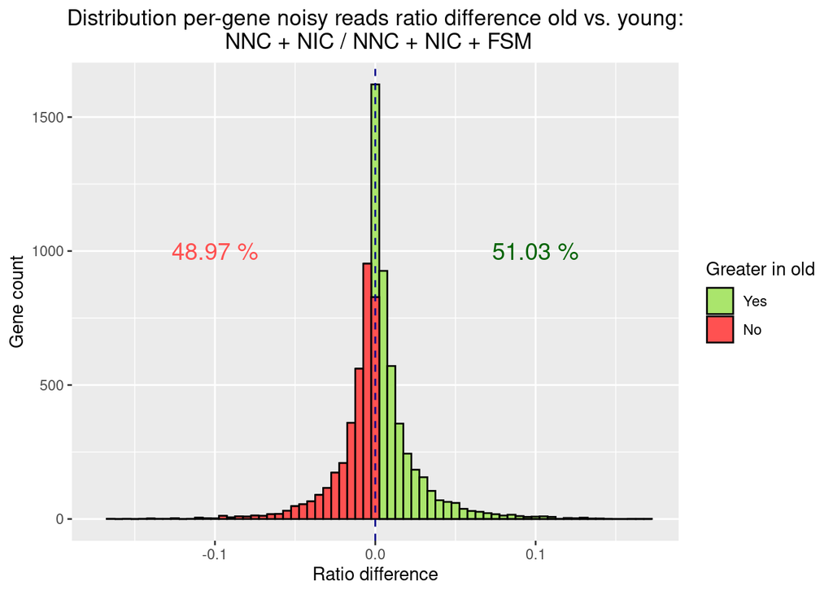

```r
data <- read.table("/home/carblan/Documents/R_files/TFM/FSM>=10_intersection_filtered_genes/per_gene_noisy_reads_ratio/noisy_reads_ratio_difference_per_gene.txt", header = TRUE)
histogram <- RBN_histogram(data)
print(histogram)
```

## 2.2 RBN correlation with average length and number of exons

To understand the relationship between gene length or number of exons with RBN (RNA biological noise)

```r
per_gene_RBN <- read.table("/home/carblan/Documents/R_files/TFM/FSM>=10_intersection_filtered_genes/per_gene_noisy_reads_ratio/noisy_reads_ratio_difference_per_gene.txt", header = TRUE)

length_correlation <- cor(per_gene_RBN$noisy_reads_ratio_diff, per_gene_RBN$average_length, method = "spearman")
print(length_correlation)
```

```
## [1] -0.01231458
```

```r
exons_correlation <- cor(per_gene_RBN$noisy_reads_ratio_diff, per_gene_RBN$average_exons, method = "spearman")
print(exons_correlation)
```

```
## [1] 0.01169008
```

## 2.3 RBN correlation with reference length and reference gc content (all samples intersection)

The same is done, taking the length and the gc content of the gene from a reference, instead of calculating the length and the number of exons from the transcript models data.

```r
# Use the per gene noisy reads ratio difference file to extract the gene symbols,
# change them for their corresponding ENTREZID, and substitute the length column
# with the corresponding lengths from the reference using EDASeq. Also adds the
# GC content.

per_gene_RBN <- read.table("/home/carblan/Documents/R_files/TFM/FSM>=10_intersection_filtered_genes/per_gene_noisy_reads_ratio/noisy_reads_ratio_difference_per_gene.txt", header = TRUE)

symbols <- per_gene_RBN$associated_gene

ids <- AnnotationDbi::select(EnsDb.Mmusculus.v79,
    keys = symbols,
    columns = c("ENTREZID", "SYMBOL", "GENEID"),
    keytype = "SYMBOL")

lengths_gc <- getGeneLengthAndGCContent(ids$GENEID, "mmu", mode="org.db") #Choose mart 4 (mus musculus) if you select mode=biomart (not working because lack of memory?)

# Combine the dfs
merged_df <- merge(per_gene_RBN, ids, by.x = "associated_gene", by.y = "SYMBOL")
merged_df <- merge(merged_df, lengths_gc, by.x = "GENEID", by.y = "row.names")

# Seleccionar columnas deseadas
final_df <- merged_df[, c("associated_gene", "chrom", "length", "gc", "noisy_reads_ratio_diff")][order(merged_df$associated_gene),]

final_df <- final_df %>%
  dplyr::filter(!((final_df$length == "NA")))

# correlation:
length_correlation <- cor(final_df$noisy_reads_ratio_diff, final_df$length, method = "spearman")
print(length_correlation)
```

```
## [1] -0.01708096
```

```r
gc_correlation <- cor(final_df$noisy_reads_ratio_diff, final_df$gc, method = "spearman")
print(gc_correlation)
```

```
## [1] 0.03945926
```

## 2.4 RBN correlation with read count

This is also important just to check if the noisy genes are noisy because they are truly noisy or because they just have low read count (even if the genes are filtered by FSM >= 10, the noisy genes could just be noisy because the overall read count of the gene is low)

```r
# Obtener la lista de archivos en el directorio actual
files <- list.files(path = "/home/carblan/Documents/R_files/TFM/FSM>=10_intersection_filtered_genes", pattern=".txt", full.names = TRUE)

# We first need to normalize the counts
normalize_counts <- function(file) {
  data <- read.table(file, header = TRUE)
  data$cpm <- (data$total_counts / sum(data$total_counts)) * 1e6
  return(data)
}

# Leer y normalizar todos los archivos, manteniendo solo las columnas necesarias
all_data <- lapply(files, function(file) {
  data <- normalize_counts(file)
  return(data[, c("associated_gene", "chrom", "cpm")])
})

# Combinar todos los dataframes en uno solo
combined_data <- do.call(rbind, all_data)

# Calcular la mediana de los "cpm" para cada "associated_gene" y "chrom"
median_cpm_data <- aggregate(cpm ~ associated_gene + chrom, data = combined_data, FUN = median)

# Renombrar la columna de la mediana
names(median_cpm_data)[names(median_cpm_data) == "cpm"] <- "median_cpm"


per_gene_RBN <- read.table("/home/carblan/Documents/R_files/TFM/FSM>=10_intersection_filtered_genes/per_gene_noisy_reads_ratio/noisy_reads_ratio_difference_per_gene.txt", header = TRUE)

combined_data <- merge(median_cpm_data, per_gene_RBN, by = c("associated_gene", "chrom"))

# Correlation
correlation <- cor(combined_data$noisy_reads_ratio_diff, combined_data$median_cpm, method = "spearman")
cat("Gene counts and length correlation (Spearman):\n", correlation, "\n")
```

```
## Gene counts and length correlation (Spearman):
##  -0.02606733
```

```r
correlation <- cor(combined_data$noisy_reads_ratio_diff, combined_data$median_cpm, method = "pearson")
cat("Gene counts and length correlation (Pearson):\n", correlation, "\n")
```

```
## Gene counts and length correlation (Pearson):
##  -0.0177824
```

# 3 Per gene noisy reads ratio difference, average length and average number of exons (only pool 1 genes)

Now we do the same but only for pool 1 samples, as we know that the percentage of genes that show more noise in old mice than young mice is 60% in pool 1 but 40% in pool 2. The genes filtered are not exclusive to pool 1, these are only all of the genes shown by all samples from pool 1 that also have 10 or more counts assigned as FSM.

```r
# Obtener la lista de archivos en el directorio actual
files <- list.files(path = "/home/carblan/Documents/R_files/TFM/filtered_per_gene_classifications",
                    full.names = TRUE)
pool_1_files <- files[str_detect(basename(files), "^B3[1-3]|^B15[1-2]")]
# Inicializar una lista para almacenar los datos filtrados
filtered_data <- list()

# Iterar sobre cada archivo
for (file in pool_1_files) {
  # Leer el archivo
  data <- read.table(file, header=TRUE, stringsAsFactors=FALSE)

  # Filtrar los genes cuyo valor en la columna "full_splice_match_counts" es menor que 10
  data <- data[data$full_splice_match_counts >= 10,]

  # Almacenar los datos filtrados
  filtered_data[[file]] <- data
}

# Obtener la lista de genes que aparecen en todos los archivos de la pool 1 con FSM>=10
associated_genes <- Reduce(intersect, lapply(filtered_data, function(x) x$associated_gene))

# Crear un directorio para los archivos filtrados si no existe
dir <- "/home/carblan/Documents/R_files/TFM/FSM>=10_pool_1_filtered_genes"
if (!dir.exists(dir)) {
  dir.create(dir)
}

# Iterar sobre cada archivo nuevamente para guardar los datos filtrados
for (file in pool_1_files) {
  # Filtrar los genes que aparecen en todos los archivos
  data <- filtered_data[[file]]
  data <- data[data$associated_gene %in% associated_genes,]

  # Guardar el archivo filtrado en la nueva ubicación
  write.table(data, file.path(dir, basename(file)), sep="\t", row.names=FALSE)
}

# Obtener la lista de archivos en el directorio actual
files <- list.files(path = "/home/carblan/Documents/R_files/TFM/FSM>=10_pool_1_filtered_genes", pattern=".txt", full.names = TRUE)

# Crear el directorio para los archivos de salida si no existe
output_dir <- "/home/carblan/Documents/R_files/TFM/FSM>=10_pool_1_filtered_genes/per_gene_structural_categories_ratios"
if (!dir.exists(output_dir)) {
  dir.create(output_dir, recursive = TRUE)
}

# Iterar sobre cada archivo
for (file in files) {
  # Leer el archivo
  data <- read.table(file, header=TRUE, stringsAsFactors=FALSE)

  # Calcular los ratios de cada categoría estructural para cada associated_gene
  categories <- colnames(data)[5:ncol(data)]
  for (category in categories) {
    data[[category]] <- data[[category]] / data$total_counts
  }

  # Guardar el archivo de salida
  output_file <- file.path(output_dir, basename(file))
  write.table(data, output_file, sep="\t", quote=FALSE, row.names=FALSE)
}

input_dir <- "/home/carblan/Documents/R_files/TFM/FSM>=10_pool_1_filtered_genes/per_gene_structural_categories_ratios"

# Obtener la lista de archivos en el directorio
files <- list.files(path = input_dir, pattern=".txt", full.names = TRUE)

# Separar los archivos por grupo (young y old)
young_files <- files[str_detect(basename(files), "^B3[1-3]")]
old_files <- files[str_detect(basename(files), "^B15[1-2]")]

# Función para calcular la media de los ratios por associated_gene y chrom
calculate_mean_ratios <- function(files) {
  # Leer los archivos y combinarlos en un solo dataframe
  data <- map_dfr(files, ~read.table(.x, header=TRUE, stringsAsFactors=FALSE))

  # Agrupar por associated_gene y chrom y calcular la media de los ratios de cada categoría estructural
  data_mean <- data %>%
    group_by(associated_gene, chrom) %>%
    summarise(across(starts_with("median_length"), mean),
            across(starts_with("median_exons"), mean),
            across(starts_with("full"), mean),
            across(starts_with("incomplete"), mean),
            across(starts_with("novel_not"), mean),
            across(starts_with("novel_in"), mean),
            across(starts_with("genic"), mean),
            total_counts = mean(total_counts),  # Calcular la media de la columna "total_counts"
            .groups = "drop") %>%
    arrange(associated_gene)  # Ordenar primero por chrom y luego por associated_gene

  return(data_mean)
}

# Calcular la media de los ratios para el grupo young
young_mean_ratios <- calculate_mean_ratios(young_files)

# Calcular la media de los ratios para el grupo old
old_mean_ratios <- calculate_mean_ratios(old_files)

# Directorio donde se guardarán los archivos de salida
output_dir <- "/home/carblan/Documents/R_files/TFM/FSM>=10_pool_1_filtered_genes/age_groups_per_gene_categories_mean_ratios"
if (!dir.exists(output_dir)) {
  dir.create(output_dir, recursive = TRUE)
}

# Guardar los resultados en archivos de salida
write.table(young_mean_ratios, file.path(output_dir, "young_mean_ratios.txt"), sep="\t", quote=FALSE, row.names=FALSE)
write.table(old_mean_ratios, file.path(output_dir, "old_mean_ratios.txt"), sep="\t", quote=FALSE, row.names=FALSE)

input_dir <- "/home/carblan/Documents/R_files/TFM/FSM>=10_pool_1_filtered_genes/age_groups_per_gene_categories_mean_ratios"

# Leer los archivos de medias de los ratios para young y old
young_mean_ratios <- read.table(file.path(input_dir, "young_mean_ratios.txt"), header=TRUE, stringsAsFactors=FALSE)
old_mean_ratios <- read.table(file.path(input_dir, "old_mean_ratios.txt"), header=TRUE, stringsAsFactors=FALSE)

# Función para calcular los "noisy reads ratios"
calculate_noisy_reads_ratios <- function(data) {
  # Calcular las métricas para cada fila
  noisy_reads_ratio <- (data$novel_in_catalog_counts + data$novel_not_in_catalog_counts) / (data$full_splice_match_counts + data$novel_in_catalog_counts + data$novel_not_in_catalog_counts)

  # Crear un nuevo dataframe con los resultados
  noisy_reads_ratios <- data.frame(
    associated_gene = data$associated_gene,
    chrom = data$chrom,
    average_length = data$median_length,
    average_exons = data$median_exons,
    noisy_reads_ratio = noisy_reads_ratio
  )

  return(noisy_reads_ratios)
}

# Calcular los "noisy reads ratios" para young y old
young_noisy_reads_ratios <- calculate_noisy_reads_ratios(young_mean_ratios)
old_noisy_reads_ratios <- calculate_noisy_reads_ratios(old_mean_ratios)

# Directorio donde se guardarán los archivos de salida
output_dir <- "/home/carblan/Documents/R_files/TFM/FSM>=10_pool_1_filtered_genes/per_gene_noisy_reads_ratio"
if (!dir.exists(output_dir)) {
  dir.create(output_dir)
}

# Guardar los resultados en archivos de salida
write.table(young_noisy_reads_ratios, file.path(output_dir, "young_noisy_reads_ratios.txt"), sep="\t", quote=FALSE, row.names=FALSE)
write.table(old_noisy_reads_ratios, file.path(output_dir, "old_noisy_reads_ratios.txt"), sep="\t", quote=FALSE, row.names=FALSE)

input_dir <- "/home/carblan/Documents/R_files/TFM/FSM>=10_pool_1_filtered_genes/per_gene_noisy_reads_ratio"

# Leer los archivos de noisy reads ratios para young y old
young_noisy_reads_ratios <- read.table(file.path(input_dir, "young_noisy_reads_ratios.txt"), header=TRUE, stringsAsFactors=FALSE)
old_noisy_reads_ratios <- read.table(file.path(input_dir, "old_noisy_reads_ratios.txt"), header=TRUE, stringsAsFactors=FALSE)

calculate_difference <- function(young_data, old_data) {
  # Combinar los dataframes por la columna associated_gene
  combined_data <- merge(old_data, young_data, by = "associated_gene", suffixes = c("_old", "_young"))

  # Calcular las diferencias para cada métrica
  noisy_reads_ratio_diff <- combined_data$noisy_reads_ratio_old - combined_data$noisy_reads_ratio_young

  # Calcular la media de average_length y average_exons para cada associated_gene
  media_average_length <- rowMeans(combined_data[, c("average_length_old", "average_length_young")], na.rm = TRUE)
  media_average_exons <- rowMeans(combined_data[, c("average_exons_old", "average_exons_young")], na.rm = TRUE)

  # Construir el dataframe noisy_reads_ratio_difference con las medias calculadas
  noisy_reads_ratio_difference <- data.frame(
    associated_gene = combined_data$associated_gene,
    chrom = combined_data$chrom_old,  # Puedes elegir la columna chrom de old_data o young_data
    average_length = media_average_length,
    average_exons = media_average_exons,
    noisy_reads_ratio_diff = noisy_reads_ratio_diff
  )

  return(noisy_reads_ratio_difference)
}

# Calcular las diferencias de noisy reads ratios
noisy_reads_ratio_difference <- calculate_difference(young_noisy_reads_ratios, old_noisy_reads_ratios)

# Directorio donde se guardará el archivo de salida
output_dir <- "/home/carblan/Documents/R_files/TFM/FSM>=10_pool_1_filtered_genes/per_gene_noisy_reads_ratio"
if (!dir.exists(output_dir)) {
  dir.create(output_dir)
}

# Guardar los resultados en un archivo de salida
write.table(noisy_reads_ratio_difference, file.path(output_dir, "noisy_reads_ratio_difference_per_gene.txt"), sep="\t", quote=FALSE, row.names=FALSE)
```

## 3.1 Per gene noisy reads ratio difference distribution

```r
# Function
RBN_histogram <- function(data) {
  # Filtramos los valores diferentes de 0
  data_filtrado <- data[complete.cases(data) & data$noisy_reads_ratio_diff != 0, ]

  # Calculamos el porcentaje de genes por encima y por debajo de 0
  genes_above_0 <- sum(data_filtrado[, "noisy_reads_ratio_diff"] > 0)
  genes_below_0 <- sum(data_filtrado[, "noisy_reads_ratio_diff"] < 0)
  total_genes <- nrow(data_filtrado)
  porcentaje_above_0 <- round((genes_above_0 / total_genes) * 100, 2)
  porcentaje_below_0 <- round((genes_below_0 / total_genes) * 100, 2)

  # Creamos el histograma
  histograma <- ggplot(data_filtrado, aes(x = data_filtrado[, "noisy_reads_ratio_diff"], fill = ifelse(data_filtrado[, "noisy_reads_ratio_diff"] > 0, "above_0", "below_0"))) +
    geom_histogram(binwidth = 0.01, color = "black") +
    geom_vline(xintercept = 0, color = "darkblue", linetype = "dashed") +
    labs(x = "Ratio difference", y = "Gene count", title = paste("Distribution per-gene noisy reads ratio difference old vs. young:\n", "NNC + NIC / NNC + NIC + FSM")) +
    scale_fill_manual(name = "Greater in old", values = c("above_0" = "#aae56c", "below_0" = "#ff5151"), labels = c("Yes", "No")) +
    coord_cartesian(xlim = c(-max(abs(data_filtrado[, "noisy_reads_ratio_diff"])), max(abs(data_filtrado[, "noisy_reads_ratio_diff"])))) +
    annotate("text", x = -0.2, y = 1500, label = paste(porcentaje_below_0, "%"), color = "#ff5151", size = 5) +
    annotate("text", x = 0.2, y = 1500, label = paste(porcentaje_above_0, "%"), color = "darkgreen", size = 5) +
    theme(plot.title = element_text(hjust = 0.5))

  return(histograma)
}
```

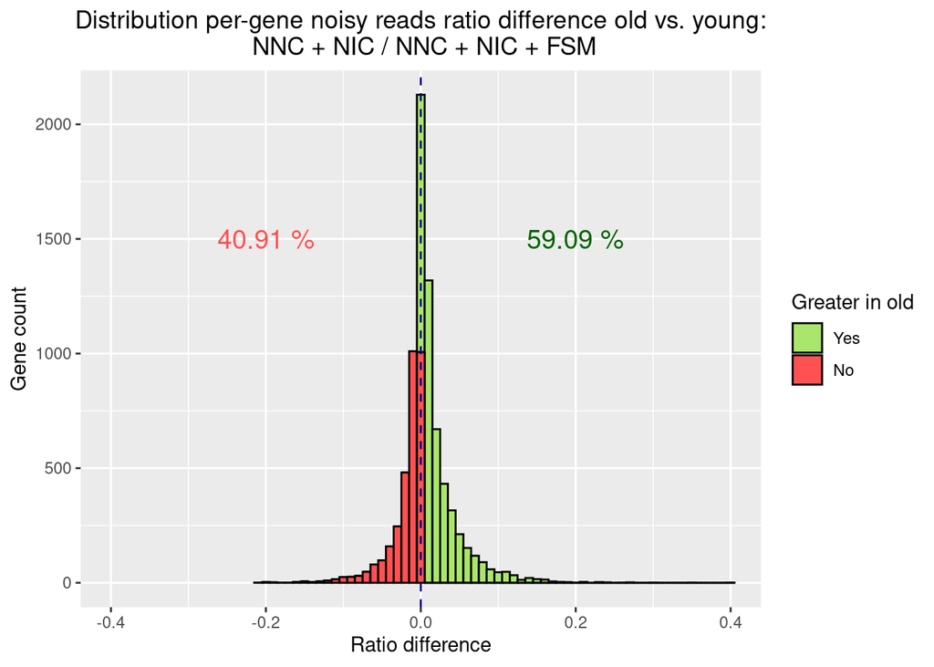

```r
data <- read.table("/home/carblan/Documents/R_files/TFM/FSM>=10_pool_1_filtered_genes/per_gene_noisy_reads_ratio/noisy_reads_ratio_difference_per_gene.txt", header = TRUE)
histogram <- RBN_histogram(data)
print(histogram)
```

## 3.2 RBN correlation with average length and number of exons

To understand the relationship between gene length or number of exons with RBN (RNA biological noise)

```r
per_gene_RBN <- read.table("/home/carblan/Documents/R_files/TFM/FSM>=10_pool_1_filtered_genes/per_gene_noisy_reads_ratio/noisy_reads_ratio_difference_per_gene.txt", header = TRUE)

length_correlation <- cor(per_gene_RBN$noisy_reads_ratio_diff, per_gene_RBN$average_length, method = "spearman")
print(length_correlation)
```

```
## [1] -0.007737177
```

```r
exons_correlation <- cor(per_gene_RBN$noisy_reads_ratio_diff, per_gene_RBN$average_exons, method = "spearman")
print(exons_correlation)
```

```
## [1] 0.08871304
```

The same is done, taking the length and the gc content of the gene from a reference, instead of calculating the length and the number of exons from the transcript models data.

```r
# Use the per gene noisy reads ratio difference file to extract the gene symbols,
# change them for their corresponding ENTREZID, and substitute the length column
# with the corresponding lengths from the reference using EDASeq. Also adds the
# GC content.

per_gene_RBN <- read.table("/home/carblan/Documents/R_files/TFM/FSM>=10_pool_1_filtered_genes/per_gene_noisy_reads_ratio/noisy_reads_ratio_difference_per_gene.txt", header = TRUE)

symbols <- per_gene_RBN$associated_gene

ids <- AnnotationDbi::select(EnsDb.Mmusculus.v79,
    keys = symbols,
    columns = c("ENTREZID", "SYMBOL", "GENEID"),
    keytype = "SYMBOL")

lengths_gc <- getGeneLengthAndGCContent(ids$GENEID, "mmu", mode="org.db") #Choose mart 4 (mus musculus) if you select mode=biomart (not working because lack of memory?)

# Combine the dfs
merged_df <- merge(per_gene_RBN, ids, by.x = "associated_gene", by.y = "SYMBOL")
merged_df <- merge(merged_df, lengths_gc, by.x = "GENEID", by.y = "row.names")

# Seleccionar columnas deseadas
final_df <- merged_df[, c("associated_gene", "chrom", "length", "gc", "noisy_reads_ratio_diff")][order(merged_df$associated_gene),]

final_df <- final_df %>%
  dplyr::filter(!((final_df$length == "NA")))

# correlation:
length_correlation <- cor(final_df$noisy_reads_ratio_diff, final_df$length, method = "spearman")
print(length_correlation)
```

```
## [1] 0.002219582
```

```r
gc_correlation <- cor(final_df$noisy_reads_ratio_diff, final_df$gc, method = "spearman")
print(gc_correlation)
```

```
## [1] 0.02047123
```

## 3.4 RBN correlation with read count

This is also important just to check if the noisy genes are noisy because they are truly noisy or because they just have low read count (even if the genes are filtered by FSM >= 10, the noisy genes could just be noisy because the overall read count of the gene is low)

```r
# Obtener la lista de archivos en el directorio actual
files <- list.files(path = "/home/carblan/Documents/R_files/TFM/FSM>=10_pool_1_filtered_genes", pattern=".txt", full.names = TRUE)

# We first need to normalize the counts
normalize_counts <- function(file) {
  data <- read.table(file, header = TRUE)
  data$cpm <- (data$total_counts / sum(data$total_counts)) * 1e6
  return(data)
}

# Leer y normalizar todos los archivos, manteniendo solo las columnas necesarias
all_data <- lapply(files, function(file) {
  data <- normalize_counts(file)
  return(data[, c("associated_gene", "chrom", "cpm")])
})

# Combinar todos los dataframes en uno solo
combined_data <- do.call(rbind, all_data)

# Calcular la mediana de los "cpm" para cada "associated_gene" y "chrom"
median_cpm_data <- aggregate(cpm ~ associated_gene + chrom, data = combined_data, FUN = median)

# Renombrar la columna de la mediana
names(median_cpm_data)[names(median_cpm_data) == "cpm"] <- "median_cpm"


per_gene_RBN <- read.table("/home/carblan/Documents/R_files/TFM/FSM>=10_pool_1_filtered_genes/per_gene_noisy_reads_ratio/noisy_reads_ratio_difference_per_gene.txt", header = TRUE)

combined_data <- merge(median_cpm_data, per_gene_RBN, by = c("associated_gene", "chrom"))

# Correlation
correlation <- cor(combined_data$noisy_reads_ratio_diff, combined_data$median_cpm, method = "spearman")
cat("Gene counts and length correlation (Spearman):\n", correlation, "\n")
```

```
## Gene counts and length correlation (Spearman):
##  -0.006438679
```

```r
correlation <- cor(combined_data$noisy_reads_ratio_diff, combined_data$median_cpm, method = "pearson")
cat("Gene counts and length correlation (Pearson):\n", correlation, "\n")
```

```
## Gene counts and length correlation (Pearson):
##  -0.03740211
```

# 4 Per gene noisy reads ratio difference, average length and average number of exons (only pool 2 genes)

Now we do the same but only for pool 2 samples, as we know that the percentage of genes that show more noise in old mice than young mice is 60% in pool 1 but 40% in pool 2. The genes filtered are not exclusive to pool 2, these are only all of the genes shown by all samples from pool 2 that also have 10 or more counts assigned as FSM.

```r
# Obtener la lista de archivos en el directorio actual
files <- list.files(path = "/home/carblan/Documents/R_files/TFM/filtered_per_gene_classifications",
                    full.names = TRUE)
pool_2_files <- files[str_detect(basename(files), "^B3[4-5]|^B15[3-4]")]
# Inicializar una lista para almacenar los datos filtrados
filtered_data <- list()

# Iterar sobre cada archivo
for (file in pool_2_files) {
  # Leer el archivo
  data <- read.table(file, header=TRUE, stringsAsFactors=FALSE)

  # Filtrar los genes cuyo valor en la columna "full_splice_match_counts" es menor que 10
  data <- data[data$full_splice_match_counts >= 10,]

  # Almacenar los datos filtrados
  filtered_data[[file]] <- data
}

# Obtener la lista de genes que aparecen en todos los archivos de la pool 1 con FSM>=10
associated_genes <- Reduce(intersect, lapply(filtered_data, function(x) x$associated_gene))

# Crear un directorio para los archivos filtrados si no existe
dir <- "/home/carblan/Documents/R_files/TFM/FSM>=10_pool_2_filtered_genes"
if (!dir.exists(dir)) {
  dir.create(dir)
}

# Iterar sobre cada archivo nuevamente para guardar los datos filtrados
for (file in pool_2_files) {
  # Filtrar los genes que aparecen en todos los archivos
  data <- filtered_data[[file]]
  data <- data[data$associated_gene %in% associated_genes,]

  # Guardar el archivo filtrado en la nueva ubicación
  write.table(data, file.path(dir, basename(file)), sep="\t", row.names=FALSE)
}

# Obtener la lista de archivos en el directorio actual
files <- list.files(path = "/home/carblan/Documents/R_files/TFM/FSM>=10_pool_2_filtered_genes", pattern=".txt", full.names = TRUE)

# Crear el directorio para los archivos de salida si no existe
output_dir <- "/home/carblan/Documents/R_files/TFM/FSM>=10_pool_2_filtered_genes/per_gene_structural_categories_ratios"
if (!dir.exists(output_dir)) {
  dir.create(output_dir, recursive = TRUE)
}

# Iterar sobre cada archivo
for (file in files) {
  # Leer el archivo
  data <- read.table(file, header=TRUE, stringsAsFactors=FALSE)

  # Calcular los ratios de cada categoría estructural para cada associated_gene
  categories <- colnames(data)[5:ncol(data)]
  for (category in categories) {
    data[[category]] <- data[[category]] / data$total_counts
  }

  # Guardar el archivo de salida
  output_file <- file.path(output_dir, basename(file))
  write.table(data, output_file, sep="\t", quote=FALSE, row.names=FALSE)
}

input_dir <- "/home/carblan/Documents/R_files/TFM/FSM>=10_pool_2_filtered_genes/per_gene_structural_categories_ratios"

# Obtener la lista de archivos en el directorio
files <- list.files(path = input_dir, pattern=".txt", full.names = TRUE)

# Separar los archivos por grupo (young y old)
young_files <- files[str_detect(basename(files), "^B3[4-5]")]
old_files <- files[str_detect(basename(files), "^B15[3-4]")]

# Función para calcular la media de los ratios por associated_gene y chrom
calculate_mean_ratios <- function(files) {
  # Leer los archivos y combinarlos en un solo dataframe
  data <- map_dfr(files, ~read.table(.x, header=TRUE, stringsAsFactors=FALSE))

  # Agrupar por associated_gene y chrom y calcular la media de los ratios de cada categoría estructural
  data_mean <- data %>%
    group_by(associated_gene, chrom) %>%
    summarise(across(starts_with("median_length"), mean),
            across(starts_with("median_exons"), mean),
            across(starts_with("full"), mean),
            across(starts_with("incomplete"), mean),
            across(starts_with("novel_not"), mean),
            across(starts_with("novel_in"), mean),
            across(starts_with("genic"), mean),
            total_counts = mean(total_counts),  # Calcular la media de la columna "total_counts"
            .groups = "drop") %>%
    arrange(associated_gene)  # Ordenar por associated_gene

  return(data_mean)
}

# Calcular la media de los ratios para el grupo young
young_mean_ratios <- calculate_mean_ratios(young_files)

# Calcular la media de los ratios para el grupo old
old_mean_ratios <- calculate_mean_ratios(old_files)

# Directorio donde se guardarán los archivos de salida
output_dir <- "/home/carblan/Documents/R_files/TFM/FSM>=10_pool_2_filtered_genes/age_groups_per_gene_categories_mean_ratios"
if (!dir.exists(output_dir)) {
  dir.create(output_dir, recursive = TRUE)
}

# Guardar los resultados en archivos de salida
write.table(young_mean_ratios, file.path(output_dir, "young_mean_ratios.txt"), sep="\t", quote=FALSE, row.names=FALSE)
write.table(old_mean_ratios, file.path(output_dir, "old_mean_ratios.txt"), sep="\t", quote=FALSE, row.names=FALSE)

input_dir <- "/home/carblan/Documents/R_files/TFM/FSM>=10_pool_2_filtered_genes/age_groups_per_gene_categories_mean_ratios"

# Leer los archivos de medias de los ratios para young y old
young_mean_ratios <- read.table(file.path(input_dir, "young_mean_ratios.txt"), header=TRUE, stringsAsFactors=FALSE)
old_mean_ratios <- read.table(file.path(input_dir, "old_mean_ratios.txt"), header=TRUE, stringsAsFactors=FALSE)

# Función para calcular los "noisy reads ratios"
calculate_noisy_reads_ratios <- function(data) {
  # Calcular las métricas para cada fila
  noisy_reads_ratio <- (data$novel_in_catalog_counts + data$novel_not_in_catalog_counts) / (data$full_splice_match_counts + data$novel_in_catalog_counts + data$novel_not_in_catalog_counts)

  # Crear un nuevo dataframe con los resultados
  noisy_reads_ratios <- data.frame(
    associated_gene = data$associated_gene,
    chrom = data$chrom,
    average_length = data$median_length,
    average_exons = data$median_exons,
    noisy_reads_ratio = noisy_reads_ratio
  )

  return(noisy_reads_ratios)
}

# Calcular los "noisy reads ratios" para young y old
young_noisy_reads_ratios <- calculate_noisy_reads_ratios(young_mean_ratios)
old_noisy_reads_ratios <- calculate_noisy_reads_ratios(old_mean_ratios)

# Directorio donde se guardarán los archivos de salida
output_dir <- "/home/carblan/Documents/R_files/TFM/FSM>=10_pool_2_filtered_genes/per_gene_noisy_reads_ratio"
if (!dir.exists(output_dir)) {
  dir.create(output_dir)
}

# Guardar los resultados en archivos de salida
write.table(young_noisy_reads_ratios, file.path(output_dir, "young_noisy_reads_ratios.txt"), sep="\t", quote=FALSE, row.names=FALSE)
write.table(old_noisy_reads_ratios, file.path(output_dir, "old_noisy_reads_ratios.txt"), sep="\t", quote=FALSE, row.names=FALSE)

input_dir <- "/home/carblan/Documents/R_files/TFM/FSM>=10_pool_2_filtered_genes/per_gene_noisy_reads_ratio"

# Leer los archivos de noisy reads ratios para young y old
young_noisy_reads_ratios <- read.table(file.path(input_dir, "young_noisy_reads_ratios.txt"), header=TRUE, stringsAsFactors=FALSE)
old_noisy_reads_ratios <- read.table(file.path(input_dir, "old_noisy_reads_ratios.txt"), header=TRUE, stringsAsFactors=FALSE)

calculate_difference <- function(young_data, old_data) {
  # Combinar los dataframes por la columna associated_gene
  combined_data <- merge(old_data, young_data, by = "associated_gene", suffixes = c("_old", "_young"))

  # Calcular las diferencias para cada métrica
  noisy_reads_ratio_diff <- combined_data$noisy_reads_ratio_old - combined_data$noisy_reads_ratio_young

  # Calcular la media de average_length y average_exons para cada associated_gene
  media_average_length <- rowMeans(combined_data[, c("average_length_old", "average_length_young")], na.rm = TRUE)
  media_average_exons <- rowMeans(combined_data[, c("average_exons_old", "average_exons_young")], na.rm = TRUE)

  # Construir el dataframe noisy_reads_ratio_difference con las medias calculadas
  noisy_reads_ratio_difference <- data.frame(
    associated_gene = combined_data$associated_gene,
    chrom = combined_data$chrom_old,  # Puedes elegir la columna chrom de old_data o young_data
    average_length = media_average_length,
    average_exons = media_average_exons,
    noisy_reads_ratio_diff = noisy_reads_ratio_diff
  )

  return(noisy_reads_ratio_difference)
}

# Calcular las diferencias de noisy reads ratios
noisy_reads_ratio_difference <- calculate_difference(young_noisy_reads_ratios, old_noisy_reads_ratios)

# Directorio donde se guardará el archivo de salida
output_dir <- "/home/carblan/Documents/R_files/TFM/FSM>=10_pool_2_filtered_genes/per_gene_noisy_reads_ratio"
if (!dir.exists(output_dir)) {
  dir.create(output_dir)
}

# Guardar los resultados en un archivo de salida
write.table(noisy_reads_ratio_difference, file.path(output_dir, "noisy_reads_ratio_difference_per_gene.txt"), sep="\t", quote=FALSE, row.names=FALSE)
```

## 4.1 Per gene noisy reads ratio difference distribution

```r
# Function
RBN_histogram <- function(data) {
  # Filtramos los valores diferentes de 0
  data_filtrado <- data[complete.cases(data) & data$noisy_reads_ratio_diff != 0, ]

  # Calculamos el porcentaje de genes por encima y por debajo de 0
  genes_above_0 <- sum(data_filtrado[, "noisy_reads_ratio_diff"] > 0)
  genes_below_0 <- sum(data_filtrado[, "noisy_reads_ratio_diff"] < 0)
  total_genes <- nrow(data_filtrado)
  porcentaje_above_0 <- round((genes_above_0 / total_genes) * 100, 2)
  porcentaje_below_0 <- round((genes_below_0 / total_genes) * 100, 2)

  # Creamos el histograma
  histograma <- ggplot(data_filtrado, aes(x = data_filtrado[, "noisy_reads_ratio_diff"], fill = ifelse(data_filtrado[, "noisy_reads_ratio_diff"] > 0, "above_0", "below_0"))) +
    geom_histogram(binwidth = 0.01, color = "black") +
    geom_vline(xintercept = 0, color = "darkblue", linetype = "dashed") +
    labs(x = "Ratio difference", y = "Gene count", title = paste("Distribution per-gene noisy reads ratio difference old vs. young:\n", "NNC + NIC / NNC + NIC + FSM")) +
    scale_fill_manual(name = "Greater in old", values = c("above_0" = "#aae56c", "below_0" = "#ff5151"), labels = c("Yes", "No")) +
    coord_cartesian(xlim = c(-max(abs(data_filtrado[, "noisy_reads_ratio_diff"])), max(abs(data_filtrado[, "noisy_reads_ratio_diff"])))) +
    annotate("text", x = -0.25, y = 1250, label = paste(porcentaje_below_0, "%"), color = "#ff5151", size = 5) +
    annotate("text", x = 0.25, y = 1250, label = paste(porcentaje_above_0, "%"), color = "darkgreen", size = 5) +
    theme(plot.title = element_text(hjust = 0.5))

  return(histograma)
}
```

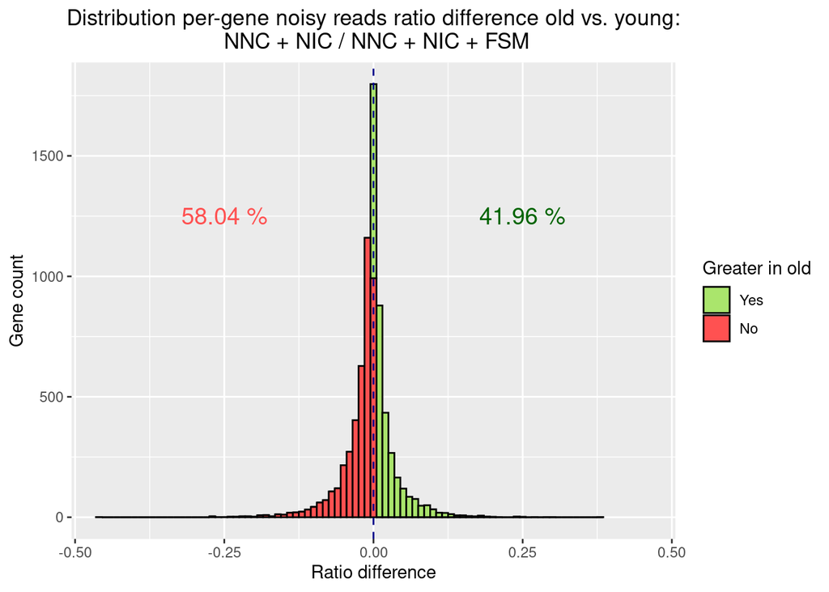

```r
data <- read.table("/home/carblan/Documents/R_files/TFM/FSM>=10_pool_2_filtered_genes/per_gene_noisy_reads_ratio/noisy_reads_ratio_difference_per_gene.txt", header = TRUE)
histogram <- RBN_histogram(data)
print(histogram)
```

## 4.2 RBN correlation with average length and number of exons

To understand the relationship between gene length or number of exons with RBN (RNA biological noise)

```r
per_gene_RBN <- read.table("/home/carblan/Documents/R_files/TFM/FSM>=10_pool_2_filtered_genes/per_gene_noisy_reads_ratio/noisy_reads_ratio_difference_per_gene.txt", header = TRUE)

length_correlation <- cor(per_gene_RBN$noisy_reads_ratio_diff, per_gene_RBN$average_length, method = "spearman")
print(length_correlation)
```

```
## [1] 0.006989647
```

```r
exons_correlation <- cor(per_gene_RBN$noisy_reads_ratio_diff, per_gene_RBN$average_exons, method = "spearman")
print(exons_correlation)
```

```
## [1] -0.07666275
```

The same is done, taking the length and the gc content of the gene from a reference, instead of calculating the length and the number of exons from the transcript models data.

```r
# Use the per gene noisy reads ratio difference file to extract the gene symbols,
# change them for their corresponding ENTREZID, and substitute the length column
# with the corresponding lengths from the reference using EDASeq. Also adds the
# GC content.

per_gene_RBN <- read.table("/home/carblan/Documents/R_files/TFM/FSM>=10_pool_2_filtered_genes/per_gene_noisy_reads_ratio/noisy_reads_ratio_difference_per_gene.txt", header = TRUE)

symbols <- per_gene_RBN$associated_gene

ids <- AnnotationDbi::select(EnsDb.Mmusculus.v79,
    keys = symbols,
    columns = c("ENTREZID", "SYMBOL", "GENEID"),
    keytype = "SYMBOL")

lengths_gc <- getGeneLengthAndGCContent(ids$GENEID, "mmu", mode="org.db") #Choose mart 4 (mus musculus) if you select mode=biomart (not working because lack of memory?)

# Combine the dfs
merged_df <- merge(per_gene_RBN, ids, by.x = "associated_gene", by.y = "SYMBOL")
merged_df <- merge(merged_df, lengths_gc, by.x = "GENEID", by.y = "row.names")

# Seleccionar columnas deseadas
final_df <- merged_df[, c("associated_gene", "chrom", "length", "gc", "noisy_reads_ratio_diff")][order(merged_df$associated_gene),]

final_df <- final_df %>%
  dplyr::filter(!((final_df$length == "NA")))

# correlation:
length_correlation <- cor(final_df$noisy_reads_ratio_diff, final_df$length, method = "spearman")
print(length_correlation)
```

```
## [1] -0.01766384
```

```r
gc_correlation <- cor(final_df$noisy_reads_ratio_diff, final_df$gc, method = "spearman")
print(gc_correlation)
```

```
## [1] 0.01668814
```

## 4.4 RBN correlation with read count

This is also important just to check if the noisy genes are noisy because they are truly noisy or because they just have low read count (even if the genes are filtered by FSM >= 10, the noisy genes could just be noisy because the overall read count of the gene is low)

```r
# Obtener la lista de archivos en el directorio actual
files <- list.files(path = "/home/carblan/Documents/R_files/TFM/FSM>=10_pool_2_filtered_genes", pattern=".txt", full.names = TRUE)

# We first need to normalize the counts
normalize_counts <- function(file) {
  data <- read.table(file, header = TRUE)
  data$cpm <- (data$total_counts / sum(data$total_counts)) * 1e6
  return(data)
}

# Leer y normalizar todos los archivos, manteniendo solo las columnas necesarias
all_data <- lapply(files, function(file) {
  data <- normalize_counts(file)
  return(data[, c("associated_gene", "chrom", "cpm")])
})

# Combinar todos los dataframes en uno solo
combined_data <- do.call(rbind, all_data)

# Calcular la mediana de los "cpm" para cada "associated_gene" y "chrom"
median_cpm_data <- aggregate(cpm ~ associated_gene + chrom, data = combined_data, FUN = median)

# Renombrar la columna de la mediana
names(median_cpm_data)[names(median_cpm_data) == "cpm"] <- "median_cpm"


per_gene_RBN <- read.table("/home/carblan/Documents/R_files/TFM/FSM>=10_pool_2_filtered_genes/per_gene_noisy_reads_ratio/noisy_reads_ratio_difference_per_gene.txt", header = TRUE)

combined_data <- merge(median_cpm_data, per_gene_RBN, by = c("associated_gene", "chrom"))

# Correlation
correlation <- cor(combined_data$noisy_reads_ratio_diff, combined_data$median_cpm, method = "spearman")
cat("Gene counts and length correlation (Spearman):\n", correlation, "\n")
```

```
## Gene counts and length correlation (Spearman):
##  -0.04446071
```

```r
correlation <- cor(combined_data$noisy_reads_ratio_diff, combined_data$median_cpm, method = "pearson")
cat("Gene counts and length correlation (Pearson):\n", correlation, "\n")
```

```
## Gene counts and length correlation (Pearson):
##  0.007296732
```

# 5 Per gene noisy reads ratio difference, average length and average number of exons (intersection, but pool 1 read counts only)

Now we will do the same than with the intersection, but taking the counts only from pool 1. With this we want to check whether this genes behave the same way with the pool 1 data or behave the same as in the intersection. The percentages should be the same with the same genes, cause technically the pool 1 has selected longer transcripts, but the genes are the same, so the transcripts selected in either pool should have the same ratios.

```r
files <- list.files(path = "/home/carblan/Documents/R_files/TFM/filtered_per_gene_classifications",
                    full.names = TRUE)
# Inicializar una lista para almacenar los datos filtrados
filtered_data <- list()

# Iterar sobre cada archivo
for (file in files) {
  # Leer el archivo
  data <- read.table(file, header=TRUE, stringsAsFactors=FALSE)

  # Filtrar los genes cuyo valor en la columna "full_splice_match_counts" es menor que 10
  data <- data[data$full_splice_match_counts >= 10,]

  # Almacenar los datos filtrados
  filtered_data[[file]] <- data
}

# Obtener la lista de genes que aparecen en todos los archivos con FSM>=10
associated_genes <- Reduce(intersect, lapply(filtered_data, function(x) x$associated_gene))

files <- list.files(path = "/home/carblan/Documents/R_files/TFM/FSM>=10_intersection_filtered_genes/per_gene_structural_categories_ratios", pattern=".txt", full.names = TRUE)

young_files_pool1 <- files[str_detect(basename(files), "^B3[1-3]")]
old_files_pool1 <- files[str_detect(basename(files), "^B15[1-2]")]

# Función para calcular la media de los ratios por associated_gene y chrom
calculate_mean_ratios <- function(files) {
  # Leer los archivos y combinarlos en un solo dataframe
  data <- map_dfr(files, ~read.table(.x, header=TRUE, stringsAsFactors=FALSE))

  # Agrupar por associated_gene y chrom y calcular la media de los ratios de cada categoría estructural
  data_mean <- data %>%
    group_by(associated_gene, chrom) %>%
    summarise(across(starts_with("median_length"), mean),
            across(starts_with("median_exons"), mean),
            across(starts_with("full"), mean),
            across(starts_with("incomplete"), mean),
            across(starts_with("novel_not"), mean),
            across(starts_with("novel_in"), mean),
            across(starts_with("genic"), mean),
            total_counts = mean(total_counts),  # Calcular la media de la columna "total_counts"
            .groups = "drop") %>%
    arrange(associated_gene)  # Ordenar primero por chrom y luego por associated_gene

  return(data_mean)
}

# Calcular la media de los ratios para el grupo young
young_mean_ratios_pool1 <- calculate_mean_ratios(young_files_pool1)

# Calcular la media de los ratios para el grupo old
old_mean_ratios_pool1 <- calculate_mean_ratios(old_files_pool1)

# Función para calcular los "noisy reads ratios"
calculate_noisy_reads_ratios <- function(data) {
  # Calcular las métricas para cada fila
  noisy_reads_ratio <- (data$novel_in_catalog_counts + data$novel_not_in_catalog_counts) / (data$full_splice_match_counts + data$novel_in_catalog_counts + data$novel_not_in_catalog_counts)

  # Crear un nuevo dataframe con los resultados
  noisy_reads_ratios <- data.frame(
    associated_gene = data$associated_gene,
    chrom = data$chrom,
    average_length = data$median_length,
    average_exons = data$median_exons,
    noisy_reads_ratio = noisy_reads_ratio
  )

  return(noisy_reads_ratios)
}

# Calcular los "noisy reads ratios" para young y old
young_noisy_reads_ratios_pool1 <- calculate_noisy_reads_ratios(young_mean_ratios_pool1)
old_noisy_reads_ratios_pool1 <- calculate_noisy_reads_ratios(old_mean_ratios_pool1)


calculate_difference <- function(young_data, old_data) {
  # Combinar los dataframes por la columna associated_gene
  combined_data <- merge(old_data, young_data, by = "associated_gene", suffixes = c("_old", "_young"))

  # Calcular las diferencias para cada métrica
  noisy_reads_ratio_diff <- combined_data$noisy_reads_ratio_old - combined_data$noisy_reads_ratio_young

  # Calcular la media de average_length y average_exons para cada associated_gene
  media_average_length <- rowMeans(combined_data[, c("average_length_old", "average_length_young")], na.rm = TRUE)
  media_average_exons <- rowMeans(combined_data[, c("average_exons_old", "average_exons_young")], na.rm = TRUE)

  # Construir el dataframe noisy_reads_ratio_difference con las medias calculadas
  noisy_reads_ratio_difference <- data.frame(
    associated_gene = combined_data$associated_gene,
    chrom = combined_data$chrom_old,  # Puedes elegir la columna chrom de old_data o young_data
    average_length = media_average_length,
    average_exons = media_average_exons,
    noisy_reads_ratio_diff = noisy_reads_ratio_diff
  )

  return(noisy_reads_ratio_difference)
}

# Calcular las diferencias de noisy reads ratios
noisy_reads_ratio_difference_pool1 <- calculate_difference(young_noisy_reads_ratios_pool1, old_noisy_reads_ratios_pool1)
```

## 5.1 Per gene noisy reads ratio difference distribution

```r
# Function
RBN_histogram <- function(data) {
  # Filtramos los valores diferentes de 0
  data_filtrado <- data[complete.cases(data) & data$noisy_reads_ratio_diff != 0, ]

  # Calculamos el porcentaje de genes por encima y por debajo de 0
  genes_above_0 <- sum(data_filtrado[, "noisy_reads_ratio_diff"] > 0)
  genes_below_0 <- sum(data_filtrado[, "noisy_reads_ratio_diff"] < 0)
  total_genes <- nrow(data_filtrado)
  porcentaje_above_0 <- round((genes_above_0 / total_genes) * 100, 2)
  porcentaje_below_0 <- round((genes_below_0 / total_genes) * 100, 2)

  # Creamos el histograma
  histograma <- ggplot(data_filtrado, aes(x = data_filtrado[, "noisy_reads_ratio_diff"], fill = ifelse(data_filtrado[, "noisy_reads_ratio_diff"] > 0, "above_0", "below_0"))) +
    geom_histogram(binwidth = 0.01, color = "black") +
    geom_vline(xintercept = 0, color = "darkblue", linetype = "dashed") +
    labs(x = "Ratio difference", y = "Gene count", title = paste("Distribution per-gene noisy reads ratio difference old vs. young:\n", "NNC + NIC / NNC + NIC + FSM\n", "Genes in the intersection of both pools (but only pool 1 read counts)")) +
    scale_fill_manual(name = "Greater in old", values = c("above_0" = "#aae56c", "below_0" = "#ff5151"), labels = c("Yes", "No")) +
    coord_cartesian(xlim = c(-max(abs(data_filtrado[, "noisy_reads_ratio_diff"])), max(abs(data_filtrado[, "noisy_reads_ratio_diff"])))) +
    annotate("text", x = -0.25, y = 1250, label = paste(porcentaje_below_0, "%"), color = "#ff5151", size = 5) +
    annotate("text", x = 0.25, y = 1250, label = paste(porcentaje_above_0, "%"), color = "darkgreen", size = 5) +
    theme(plot.title = element_text(hjust = 0.5))

  return(histograma)
}
```

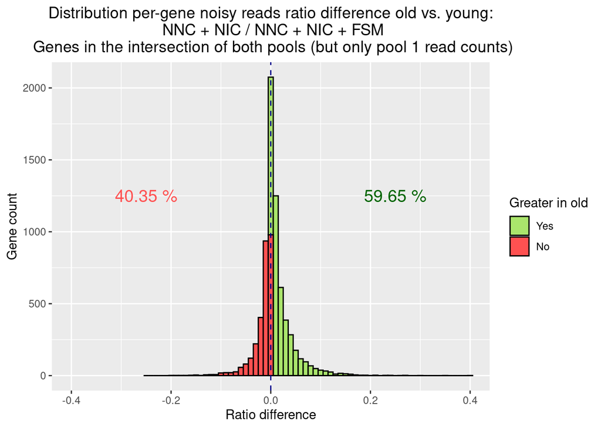

```r
histogram <- RBN_histogram(noisy_reads_ratio_difference_pool1)
print(histogram)
```

## 5.2 RBN correlation with average length and number of exons

To understand the relationship between gene length or number of exons with RBN (RNA biological noise)

```r
length_correlation <- cor(noisy_reads_ratio_difference_pool1$noisy_reads_ratio_diff, noisy_reads_ratio_difference_pool1$average_length, method = "spearman")
print(length_correlation)
```

```
## [1] -0.009500139
```

```r
exons_correlation <- cor(noisy_reads_ratio_difference_pool1$noisy_reads_ratio_diff, noisy_reads_ratio_difference_pool1$average_exons, method = "spearman")
print(exons_correlation)
```

```
## [1] 0.08789325
```

## 5.3 RBN correlation with reference length and reference gc content (all samples intersection)

The same is done, taking the length and the gc content of the gene from a reference, instead of calculating the length and the number of exons from the transcript models data.

```r
# Use the per gene noisy reads ratio difference file to extract the gene symbols,
# change them for their corresponding ENTREZID, and substitute the length column
# with the corresponding lengths from the reference using EDASeq. Also adds the
# GC content.
symbols <- noisy_reads_ratio_difference_pool1$associated_gene

ids <- AnnotationDbi::select(EnsDb.Mmusculus.v79,
    keys = symbols,
    columns = c("ENTREZID", "SYMBOL", "GENEID"),
    keytype = "SYMBOL")

lengths_gc <- getGeneLengthAndGCContent(ids$GENEID, "mmu", mode="org.db") #Choose mart 4 (mus musculus) if you select mode=biomart (not working because lack of memory?)

# Combine the dfs
merged_df <- merge(noisy_reads_ratio_difference_pool1, ids, by.x = "associated_gene", by.y = "SYMBOL")
merged_df <- merge(merged_df, lengths_gc, by.x = "GENEID", by.y = "row.names")

# Seleccionar columnas deseadas
final_df <- merged_df[, c("associated_gene", "chrom", "length", "gc", "noisy_reads_ratio_diff")][order(merged_df$associated_gene),]

final_df <- final_df %>%
  dplyr::filter(!((final_df$length == "NA")))

# correlation:
length_correlation <- cor(final_df$noisy_reads_ratio_diff, final_df$length, method = "spearman")
print(length_correlation)
```

```
## [1] -0.001960778
```

```r
gc_correlation <- cor(final_df$noisy_reads_ratio_diff, final_df$gc, method = "spearman")
print(gc_correlation)
```

```
## [1] 0.02924174
```

## 5.4 RBN correlation with read count

This is also important just to check if the noisy genes are noisy because they are truly noisy or because they just have low read count (even if the genes are filtered by FSM >= 10, the noisy genes could just be noisy because the overall read count of the gene is low)

```r
# Obtener la lista de archivos en el directorio actual
files <- list.files(path = "/home/carblan/Documents/R_files/TFM/FSM>=10_intersection_filtered_genes", pattern="B3[1-3]|B15[1-2]", full.names = TRUE)

# We first need to normalize the counts
normalize_counts <- function(file) {
  data <- read.table(file, header = TRUE)
  data$cpm <- (data$total_counts / sum(data$total_counts)) * 1e6
  return(data)
}

# Leer y normalizar todos los archivos, manteniendo solo las columnas necesarias
all_data <- lapply(files, function(file) {
  data <- normalize_counts(file)
  return(data[, c("associated_gene", "chrom", "cpm")])
})

# Combinar todos los dataframes en uno solo
combined_data <- do.call(rbind, all_data)

# Calcular la mediana de los "cpm" para cada "associated_gene" y "chrom"
median_cpm_data <- aggregate(cpm ~ associated_gene + chrom, data = combined_data, FUN = median)

# Renombrar la columna de la mediana
names(median_cpm_data)[names(median_cpm_data) == "cpm"] <- "median_cpm"


per_gene_RBN <- read.table("/home/carblan/Documents/R_files/TFM/FSM>=10_intersection_filtered_genes/per_gene_noisy_reads_ratio/noisy_reads_ratio_difference_per_gene.txt", header = TRUE)

combined_data <- merge(median_cpm_data, per_gene_RBN, by = c("associated_gene", "chrom"))

# Correlation
correlation <- cor(combined_data$noisy_reads_ratio_diff, combined_data$median_cpm, method = "spearman")
cat("Gene counts and length correlation (Spearman):\n", correlation, "\n")
```

```
## Gene counts and length correlation (Spearman):
##  -0.01935196
```

```r
correlation <- cor(combined_data$noisy_reads_ratio_diff, combined_data$median_cpm, method = "pearson")
cat("Gene counts and length correlation (Pearson):\n", correlation, "\n")
```

```
## Gene counts and length correlation (Pearson):
##  -0.01625918
```

# 6 Per gene noisy reads ratio difference, average length and average number of exons (intersection, but pool 2 read counts only)

Now we will do the same than with the intersection, but taking the counts only from pool 2. With this we want to check whether this genes behave the same way with the pool 2 data or behave the same as in the intersection. This way we can confirm that the noise compensation effect we can see with the genes in the intersection is real or if its not really a compensatory effect. If we see the same 40/60 percentage of noisy genes then we can confirm that the noise of one pool is compensating the noise of the other, resulting in the 50/50 percentage of noisy genes.

```r
files <- list.files(path = "/home/carblan/Documents/R_files/TFM/filtered_per_gene_classifications",
                    full.names = TRUE)
# Inicializar una lista para almacenar los datos filtrados
filtered_data <- list()

# Iterar sobre cada archivo
for (file in files) {
  # Leer el archivo
  data <- read.table(file, header=TRUE, stringsAsFactors=FALSE)

  # Filtrar los genes cuyo valor en la columna "full_splice_match_counts" es menor que 10
  data <- data[data$full_splice_match_counts >= 10,]

  # Almacenar los datos filtrados
  filtered_data[[file]] <- data
}

# Obtener la lista de genes que aparecen en todos los archivos con FSM>=10
associated_genes <- Reduce(intersect, lapply(filtered_data, function(x) x$associated_gene))

files <- list.files(path = "/home/carblan/Documents/R_files/TFM/FSM>=10_intersection_filtered_genes/per_gene_structural_categories_ratios", pattern=".txt", full.names = TRUE)

young_files_pool2 <- files[str_detect(basename(files), "^B3[4-5]")]
old_files_pool2 <- files[str_detect(basename(files), "^B15[3-4]")]

# Función para calcular la media de los ratios por associated_gene y chrom
calculate_mean_ratios <- function(files) {
  # Leer los archivos y combinarlos en un solo dataframe
  data <- map_dfr(files, ~read.table(.x, header=TRUE, stringsAsFactors=FALSE))

  # Agrupar por associated_gene y chrom y calcular la media de los ratios de cada categoría estructural
  data_mean <- data %>%
    group_by(associated_gene, chrom) %>%
    summarise(across(starts_with("median_length"), mean),
            across(starts_with("median_exons"), mean),
            across(starts_with("full"), mean),
            across(starts_with("incomplete"), mean),
            across(starts_with("novel_not"), mean),
            across(starts_with("novel_in"), mean),
            across(starts_with("genic"), mean),
            total_counts = mean(total_counts),  # Calcular la media de la columna "total_counts"
            .groups = "drop") %>%
    arrange(associated_gene)  # Ordenar primero por chrom y luego por associated_gene

  return(data_mean)
}

# Calcular la media de los ratios para el grupo young
young_mean_ratios_pool2 <- calculate_mean_ratios(young_files_pool2)

# Calcular la media de los ratios para el grupo old
old_mean_ratios_pool2 <- calculate_mean_ratios(old_files_pool2)

# Función para calcular los "noisy reads ratios"
calculate_noisy_reads_ratios <- function(data) {
  # Calcular las métricas para cada fila
  noisy_reads_ratio <- (data$novel_in_catalog_counts + data$novel_not_in_catalog_counts) / (data$full_splice_match_counts + data$novel_in_catalog_counts + data$novel_not_in_catalog_counts)

  # Crear un nuevo dataframe con los resultados
  noisy_reads_ratios <- data.frame(
    associated_gene = data$associated_gene,
    chrom = data$chrom,
    average_length = data$median_length,
    average_exons = data$median_exons,
    noisy_reads_ratio = noisy_reads_ratio
  )

  return(noisy_reads_ratios)
}

# Calcular los "noisy reads ratios" para young y old
young_noisy_reads_ratios_pool2 <- calculate_noisy_reads_ratios(young_mean_ratios_pool2)
old_noisy_reads_ratios_pool2 <- calculate_noisy_reads_ratios(old_mean_ratios_pool2)


calculate_difference <- function(young_data, old_data) {
  # Combinar los dataframes por la columna associated_gene
  combined_data <- merge(old_data, young_data, by = "associated_gene", suffixes = c("_old", "_young"))

  # Calcular las diferencias para cada métrica
  noisy_reads_ratio_diff <- combined_data$noisy_reads_ratio_old - combined_data$noisy_reads_ratio_young

  # Calcular la media de average_length y average_exons para cada associated_gene
  media_average_length <- rowMeans(combined_data[, c("average_length_old", "average_length_young")], na.rm = TRUE)
  media_average_exons <- rowMeans(combined_data[, c("average_exons_old", "average_exons_young")], na.rm = TRUE)

  # Construir el dataframe noisy_reads_ratio_difference con las medias calculadas
  noisy_reads_ratio_difference <- data.frame(
    associated_gene = combined_data$associated_gene,
    chrom = combined_data$chrom_old,  # Puedes elegir la columna chrom de old_data o young_data
    average_length = media_average_length,
    average_exons = media_average_exons,
    noisy_reads_ratio_diff = noisy_reads_ratio_diff
  )

  return(noisy_reads_ratio_difference)
}

# Calcular las diferencias de noisy reads ratios
noisy_reads_ratio_difference_pool2 <- calculate_difference(young_noisy_reads_ratios_pool2, old_noisy_reads_ratios_pool2)
```

## 6.1 Per gene noisy reads ratio difference distribution

```r
# Function
RBN_histogram <- function(data) {
  # Filtramos los valores diferentes de 0
  data_filtrado <- data[complete.cases(data) & data$noisy_reads_ratio_diff != 0, ]

  # Calculamos el porcentaje de genes por encima y por debajo de 0
  genes_above_0 <- sum(data_filtrado[, "noisy_reads_ratio_diff"] > 0)
  genes_below_0 <- sum(data_filtrado[, "noisy_reads_ratio_diff"] < 0)
  total_genes <- nrow(data_filtrado)
  porcentaje_above_0 <- round((genes_above_0 / total_genes) * 100, 2)
  porcentaje_below_0 <- round((genes_below_0 / total_genes) * 100, 2)

  # Creamos el histograma
  histograma <- ggplot(data_filtrado, aes(x = data_filtrado[, "noisy_reads_ratio_diff"], fill = ifelse(data_filtrado[, "noisy_reads_ratio_diff"] > 0, "above_0", "below_0"))) +
    geom_histogram(binwidth = 0.01, color = "black") +
    geom_vline(xintercept = 0, color = "darkblue", linetype = "dashed") +
    labs(x = "Ratio difference", y = "Gene count", title = paste("Distribution per-gene noisy reads ratio difference old vs. young:\n", "NNC + NIC / NNC + NIC + FSM\n", "Genes in the intersection of both pools (but only pool 2 read counts)")) +
    scale_fill_manual(name = "Greater in old", values = c("above_0" = "#aae56c", "below_0" = "#ff5151"), labels = c("Yes", "No")) +
    coord_cartesian(xlim = c(-max(abs(data_filtrado[, "noisy_reads_ratio_diff"])), max(abs(data_filtrado[, "noisy_reads_ratio_diff"])))) +
    annotate("text", x = -0.25, y = 1250, label = paste(porcentaje_below_0, "%"), color = "#ff5151", size = 5) +
    annotate("text", x = 0.25, y = 1250, label = paste(porcentaje_above_0, "%"), color = "darkgreen", size = 5) +
    theme(plot.title = element_text(hjust = 0.5))

  return(histograma)
}
```

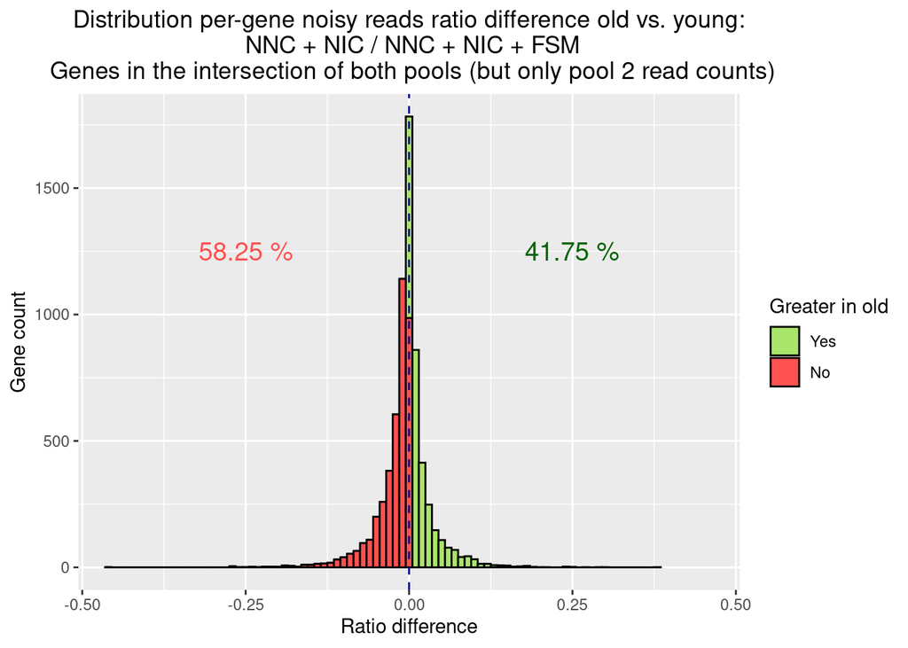

```r
histogram <- RBN_histogram(noisy_reads_ratio_difference_pool2)
print(histogram)
```

## 6.2 RBN correlation with average length and number of exons

To understand the relationship between gene length or number of exons with RBN (RNA biological noise)

```r
length_correlation <- cor(noisy_reads_ratio_difference_pool1$noisy_reads_ratio_diff, noisy_reads_ratio_difference_pool1$average_length, method = "spearman")
print(length_correlation)
```

```
## [1] -0.009500139
```

```r
exons_correlation <- cor(noisy_reads_ratio_difference_pool1$noisy_reads_ratio_diff, noisy_reads_ratio_difference_pool1$average_exons, method = "spearman")
print(exons_correlation)
```

```
## [1] 0.08789325
```

## 6.3 RBN correlation with reference length and reference gc content (all samples intersection)

The same is done, taking the length and the gc content of the gene from a reference, instead of calculating the length and the number of exons from the transcript models data.

```r
# Use the per gene noisy reads ratio difference file to extract the gene symbols,
# change them for their corresponding ENTREZID, and substitute the length column
# with the corresponding lengths from the reference using EDASeq. Also adds the
# GC content.
symbols <- noisy_reads_ratio_difference_pool1$associated_gene

ids <- AnnotationDbi::select(EnsDb.Mmusculus.v79,
    keys = symbols,
    columns = c("ENTREZID", "SYMBOL", "GENEID"),
    keytype = "SYMBOL")

lengths_gc <- getGeneLengthAndGCContent(ids$GENEID, "mmu", mode="org.db") #Choose mart 4 (mus musculus) if you select mode=biomart (not working because lack of memory?)

# Combine the dfs
merged_df <- merge(noisy_reads_ratio_difference_pool1, ids, by.x = "associated_gene", by.y = "SYMBOL")
merged_df <- merge(merged_df, lengths_gc, by.x = "GENEID", by.y = "row.names")

# Seleccionar columnas deseadas
final_df <- merged_df[, c("associated_gene", "chrom", "length", "gc", "noisy_reads_ratio_diff")][order(merged_df$associated_gene),]

final_df <- final_df %>%
  dplyr::filter(!((final_df$length == "NA")))

# correlation:
length_correlation <- cor(final_df$noisy_reads_ratio_diff, final_df$length, method = "spearman")
print(length_correlation)
```

```
## [1] -0.001960778
```

```r
gc_correlation <- cor(final_df$noisy_reads_ratio_diff, final_df$gc, method = "spearman")
print(gc_correlation)
```

```
## [1] 0.02924174
```

## 6.4 RBN correlation with read count

This is also important just to check if the noisy genes are noisy because they are truly noisy or because they just have low read count (even if the genes are filtered by FSM >= 10, the noisy genes could just be noisy because the overall read count of the gene is low)

```r
# Obtener la lista de archivos en el directorio actual
files <- list.files(path = "/home/carblan/Documents/R_files/TFM/FSM>=10_intersection_filtered_genes", pattern="B3[4-5]|B15[3-4]", full.names = TRUE)

# We first need to normalize the counts
normalize_counts <- function(file) {
  data <- read.table(file, header = TRUE)
  data$cpm <- (data$total_counts / sum(data$total_counts)) * 1e6
  return(data)
}

# Leer y normalizar todos los archivos, manteniendo solo las columnas necesarias
all_data <- lapply(files, function(file) {
  data <- normalize_counts(file)
  return(data[, c("associated_gene", "chrom", "cpm")])
})

# Combinar todos los dataframes en uno solo
combined_data <- do.call(rbind, all_data)

# Calcular la mediana de los "cpm" para cada "associated_gene" y "chrom"
median_cpm_data <- aggregate(cpm ~ associated_gene + chrom, data = combined_data, FUN = median)

# Renombrar la columna de la mediana
names(median_cpm_data)[names(median_cpm_data) == "cpm"] <- "median_cpm"


per_gene_RBN <- read.table("/home/carblan/Documents/R_files/TFM/FSM>=10_intersection_filtered_genes/per_gene_noisy_reads_ratio/noisy_reads_ratio_difference_per_gene.txt", header = TRUE)

combined_data <- merge(median_cpm_data, per_gene_RBN, by = c("associated_gene", "chrom"))

# Correlation
correlation <- cor(combined_data$noisy_reads_ratio_diff, combined_data$median_cpm, method = "spearman")
cat("Gene counts and length correlation (Spearman):\n", correlation, "\n")
```

```
## Gene counts and length correlation (Spearman):
##  -0.04339721
```

```r
correlation <- cor(combined_data$noisy_reads_ratio_diff, combined_data$median_cpm, method = "pearson")
cat("Gene counts and length correlation (Pearson):\n", correlation, "\n")
```

```
## Gene counts and length correlation (Pearson):
##  -0.0185033
```

# 7 Noisy genes comparison

```r
# Unir ambos dataframes por el id del gen
df_combined <- noisy_reads_ratio_difference_pool1 %>%
  inner_join(noisy_reads_ratio_difference_pool2, by = "associated_gene")

# Genes que aumentaron de negativo a positivo
increased_noise_genes <- df_combined %>%
  filter(noisy_reads_ratio_diff.x < 0 & noisy_reads_ratio_diff.y > 0)

# Genes que aumentaron de negativo a 0
increased_to_0_noise_genes <- df_combined %>%
  filter(noisy_reads_ratio_diff.x < 0 & noisy_reads_ratio_diff.y == 0)

# Genes que disminuyeron de positivo a negativo
decreased_noise_genes <- df_combined %>%
  filter(noisy_reads_ratio_diff.x > 0 & noisy_reads_ratio_diff.y < 0)

# Genes que disminuyeron de positivo a 0
decreased_to_0_noise_genes <- df_combined %>%
  filter(noisy_reads_ratio_diff.x > 0 & noisy_reads_ratio_diff.y == 0)

# Genes que tenían ruido 0 en el primer df y mayor a 0 en el segundo df
zero_to_positive_genes <- df_combined %>%
  filter(noisy_reads_ratio_diff.x == 0 & noisy_reads_ratio_diff.y > 0)

# Genes que tenían ruido 0 en el primer df y menor a 0 en el segundo df
zero_to_negative_genes <- df_combined %>%
  filter(noisy_reads_ratio_diff.x == 0 & noisy_reads_ratio_diff.y < 0)

# Genes que se mantuvieron en 0 o no variaron de positivo a negativo o de negativo a positivo
stable_0_genes <- df_combined %>%
  filter(noisy_reads_ratio_diff.x == 0 & noisy_reads_ratio_diff.y == 0)

stable_positive_genes <- df_combined %>%
  filter(noisy_reads_ratio_diff.x > 0 & noisy_reads_ratio_diff.y > 0)

stable_negative_genes <- df_combined %>%
  filter(noisy_reads_ratio_diff.x < 0 & noisy_reads_ratio_diff.y < 0)


# Resultados
cat("Genes que aumentaron de negativo a positivo:\n")
```

```
## Genes que aumentaron de negativo a positivo:
```

```r
#print(increased_noise_genes$associated_gene)
cat("\nTotal:", nrow(increased_noise_genes), "\n")
```

```
##
## Total: 1152
```

```r
cat("\nGenes que aumentaron de negativo a 0:\n")
```

```
##
## Genes que aumentaron de negativo a 0:
```

```r
#print(increased_to_0_noise_genes$associated_gene)
cat("\nTotal:", nrow(increased_to_0_noise_genes), "\n")
```

```
##
## Total: 199
```

```r
cat("\nGenes que disminuyeron de positivo a negativo:\n")
```

```
##
## Genes que disminuyeron de positivo a negativo:
```

```r
print(decreased_noise_genes$associated_gene)
```

[output not shown]

[output cut: 594 more lines]

```r
cat("\nTotal:", nrow(decreased_noise_genes), "\n")
```

```
##
## Total: 2435
```

```r
cat("\nTop 5 genes que más cambiaron al bajar de positivo a negativo:\n")
```

```
##
## Top 5 genes que más cambiaron al bajar de positivo a negativo:
```

```r
decreased_noise_genes$difference <- decreased_noise_genes$noisy_reads_ratio_diff.x - decreased_noise_genes$noisy_reads_ratio_diff.y
decreased_noise_genes_sorted <- decreased_noise_genes[order(-decreased_noise_genes$difference), ]
top_5_genes <- decreased_noise_genes_sorted[1:5, "associated_gene"]
print(top_5_genes)
```

```
## [1] "Fitm2"         "Pcdhgb7"       "Rnf32"         "Ddx39b"
## [5] "C330007P06Rik"
```

```r
cat("\nGenes que disminuyeron de positivo a 0:\n")
```

```
##
## Genes que disminuyeron de positivo a 0:
```

```r
#print(decreased_to_0_noise_genes$associated_gene)
cat("\nTotal:", nrow(decreased_to_0_noise_genes), "\n")
```

```
##
## Total: 186
```

```r
cat("\nGenes que tenían ruido 0 en el primer df y mayor a 0 en el segundo df:\n")
```

```
##
## Genes que tenían ruido 0 en el primer df y mayor a 0 en el segundo df:
```

```r
#print(zero_to_positive_genes$associated_gene)
cat("\nTotal:", nrow(zero_to_positive_genes), "\n")
```

```
##
## Total: 80
```

```r
cat("\nGenes que tenían ruido 0 en el primer df y menor a 0 en el segundo df:\n")
```

```
##
## Genes que tenían ruido 0 en el primer df y menor a 0 en el segundo df:
```

```r
#print(zero_to_negative_genes$associated_gene)
cat("\nTotal:", nrow(zero_to_negative_genes), "\n")
```

```
##
## Total: 73
```

```r
cat("\nGenes que se mantuvieron en 0:\n")
```

```
##
## Genes que se mantuvieron en 0:
```

```r
#print(stable_0_genes$associated_gene)
cat("\nTotal:", nrow(stable_0_genes), "\n")
```

```
##
## Total: 630
```

```r
cat("\nGenes que se mantuvieron en valores positivos:\n")
```

```
##
## Genes que se mantuvieron en valores positivos:
```

```r
#print(stable_positive_genes$associated_gene)
cat("\nTotal:", nrow(stable_positive_genes), "\n")
```

```
##
## Total: 1684
```

```r
cat("\nGenes que se mantuvieron en valores negativos:\n")
```

```
##
## Genes que se mantuvieron en valores negativos:
```

```r
#print(stable_negative_genes$associated_gene)
cat("\nTotal:", nrow(stable_negative_genes), "\n")
```

```
##
## Total: 1561
```

# 8 GSEA

## 8.1 Pools intersection

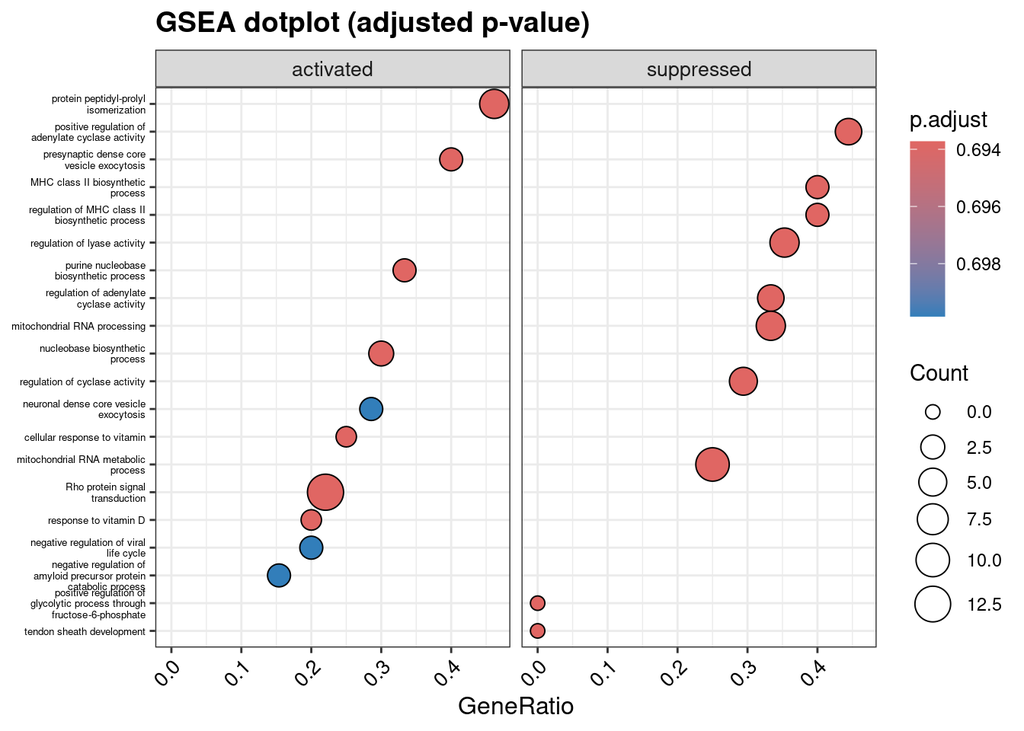

```r
df <- read.table("/home/carblan/Documents/R_files/TFM/FSM>=10_intersection_filtered_genes/per_gene_noisy_reads_ratio/noisy_reads_ratio_difference_per_gene.txt", head = TRUE)

df <- df[order(df$noisy_reads_ratio_diff, decreasing = TRUE), ]

gene_list <- df$noisy_reads_ratio_diff
names(gene_list) <- df$associated_gene

gsea_result <- gseGO(geneList = gene_list,
                     OrgDb = org.Mm.eg.db,
                     keyType = "SYMBOL",
                     ont = "BP",
                     nPerm = 10000,
                     minGSSize = 1,
                     maxGSSize = 250,
                     pvalueCutoff = 0.8,
                     pAdjustMethod = "BH",
                     verbose = TRUE)


dotplot(gsea_result, showCategory=10, split=".sign") + facet_grid(.~.sign) +
  theme(axis.text.x = element_text(angle = 45, hjust = 1, size = 10),
        axis.text.y = element_text(size = 5),
        strip.text = element_text(size = 10),
        plot.title = element_text(size = 14, face = "bold")) +
  ggtitle("GSEA dotplot (adjusted p-value)")
```

## 8.2 Pool 1

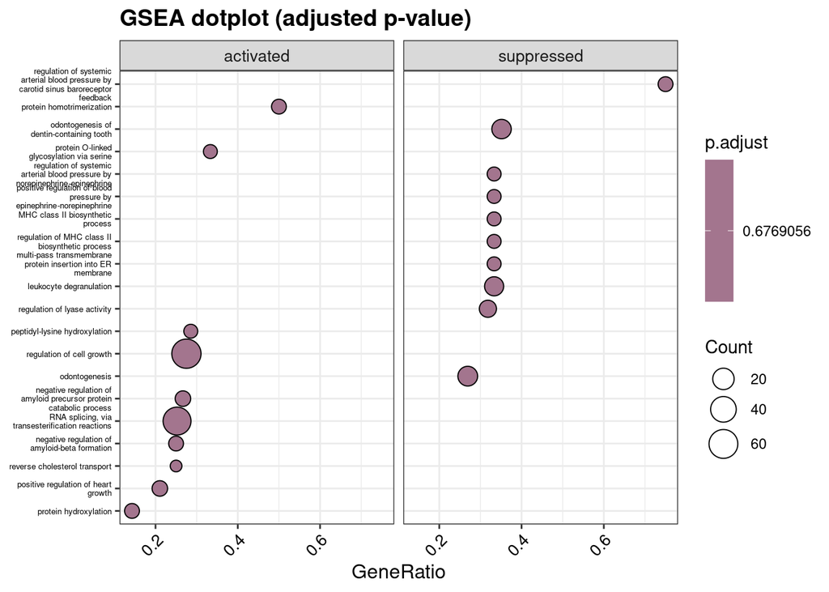

```r
df_pool1 <- read.table("/home/carblan/Documents/R_files/TFM/FSM>=10_pool_1_filtered_genes/per_gene_noisy_reads_ratio/noisy_reads_ratio_difference_per_gene.txt", head = TRUE)


df_pool1 <- df_pool1[order(df_pool1$noisy_reads_ratio_diff, decreasing = TRUE), ]


gene_list_pool1 <- df_pool1$noisy_reads_ratio_diff
names(gene_list_pool1) <- df_pool1$associated_gene


gsea_result <- gseGO(geneList = gene_list_pool1,
                     OrgDb = org.Mm.eg.db,
                     keyType = "SYMBOL",
                     ont = "BP",
                     nPerm = 10000,
                     minGSSize = 1,
                     maxGSSize = 500,
                     pvalueCutoff = 0.8,
                     pAdjustMethod = "BH",
                     verbose = TRUE)

dotplot(gsea_result, showCategory=10, split=".sign") + facet_grid(.~.sign) +
  theme(axis.text.x = element_text(angle = 45, hjust = 1, size = 10),
        axis.text.y = element_text(size = 5),
        strip.text = element_text(size = 10),
        plot.title = element_text(size = 14, face = "bold")) +
  ggtitle("GSEA dotplot (adjusted p-value)")
```

## 8.3 Pool 2

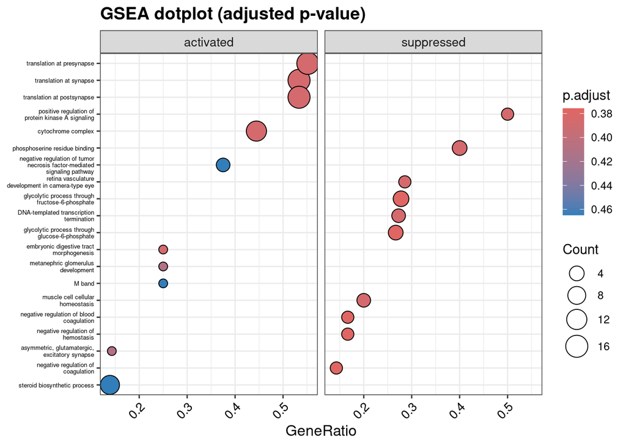

```r
df_pool2 <- read.table("/home/carblan/Documents/R_files/TFM/FSM>=10_pool_2_filtered_genes/per_gene_noisy_reads_ratio/noisy_reads_ratio_difference_per_gene.txt", head = TRUE)

df_pool2 <- df_pool2[order(df_pool2$noisy_reads_ratio_diff, decreasing = TRUE), ]

gene_list_pool2 <- df_pool2$noisy_reads_ratio_diff
names(gene_list_pool2) <- df_pool2$associated_gene

gsea_result <- gseGO(geneList = gene_list_pool2,
                     OrgDb = org.Mm.eg.db,
                     keyType = "SYMBOL",
                     ont = "ALL",
                     nPerm = 10000,
                     minGSSize = 3,
                     maxGSSize = 800,
                     pvalueCutoff = 0.8,
                     pAdjustMethod = "BH",
                     verbose = TRUE)

dotplot(gsea_result, showCategory=10, split=".sign") + facet_grid(.~.sign) +
  theme(axis.text.x = element_text(angle = 45, hjust = 1, size = 10),
        axis.text.y = element_text(size = 5),
        strip.text = element_text(size = 10),
        plot.title = element_text(size = 14, face = "bold")) +
  ggtitle("GSEA dotplot (adjusted p-value)")
```

# 9 Per gene noisy reads ratio difference (Alejandro’s pipeline, individual samples)

## 9.1 Data preparation

```r
# Classifications from SQANTI3 filter
files <- list.files(path = "/home/carblan/Documents/R_files/TFM/alejandro_filtered_classifications", pattern = "^B3[1-5]|^B15[1-4]", full.names = TRUE)

# This function filters the classifications and writes a table for each sample
process_file <- function(file) {
  # Leer el archivo
  data <- read.table(file, header = TRUE)

  # Filtrar según condiciones dadas
  data_filtered <- data %>%
    filter(!(grepl("SIRV", chrom)) & !(filter_result == "Artifact") & !(structural_category %in% c("intergenic", "antisense", "fusion", "genic_intron")))

  # Crear dataframe intermedio
  inter_df <- data_filtered %>%
    select(isoform, chrom, associated_gene, structural_category, FL, length, exons) %>%
    arrange(associated_gene)  # Ordenar por associated_gene

  # Crear dataframe final
  final_df <- inter_df %>%
    group_by(associated_gene, chrom) %>%
    summarise(median_length = median(length),
            median_exons = median(exons),
            full_splice_match_counts = sum(FL[structural_category == "full-splice_match"]),
            incomplete_splice_match_counts = sum(FL[structural_category == "incomplete-splice_match"]),
            novel_in_catalog_counts = sum(FL[structural_category == "novel_in_catalog"]),
            novel_not_in_catalog_counts = sum(FL[structural_category == "novel_not_in_catalog"]),
            genic_counts = sum(FL[structural_category == "genic"]),
            total_counts = sum(FL))

  sample_name <- sub("_.*", "", basename(file))
  output_name <- paste0(sample_name, "_per_gene_filtered_classification.txt")
  write.table(final_df, file = paste0("/home/carblan/Documents/R_files/TFM/isoseq_filtered_per_gene_classifications/", output_name), sep = "\t", row.names = FALSE)
}

dir <- "/home/carblan/Documents/R_files/TFM/isoseq_filtered_per_gene_classifications"
if (!dir.exists(dir)) {
  dir.create(dir)
}

# Procesar cada archivo
for (file in files) {
  process_file(file)
}
```

## 9.2 Intersection (pool 1 and 2 counts)

```r
files <- list.files(path = "/home/carblan/Documents/R_files/TFM/isoseq_filtered_per_gene_classifications",
                    full.names = TRUE)
# Inicializar una lista para almacenar los datos filtrados
filtered_data <- list()

# Iterar sobre cada archivo
for (file in files) {
  # Leer el archivo
  data <- read.table(file, header=TRUE, stringsAsFactors=FALSE)

  # Filtrar los genes cuyo valor en la columna "full_splice_match_counts" es menor que 10
  data <- data[data$full_splice_match_counts >= 10,]

  # Almacenar los datos filtrados
  filtered_data[[file]] <- data
}

# Obtener la lista de genes que aparecen en todos los archivos con FSM>=10
associated_genes <- Reduce(intersect, lapply(filtered_data, function(x) x$associated_gene))

# Crear un directorio para los archivos filtrados si no existe
dir <- "/home/carblan/Documents/R_files/TFM/isoseq_FSM>=10_intersection_filtered_genes"
if (!dir.exists(dir)) {
  dir.create(dir)
}

# Iterar sobre cada archivo nuevamente para guardar los datos filtrados
for (file in files) {
  # Filtrar los genes que aparecen en todos los archivos
  data <- filtered_data[[file]]
  data <- data[data$associated_gene %in% associated_genes,]

  # Guardar el archivo filtrado en la nueva ubicación
  write.table(data, file.path(dir, basename(file)), sep="\t", row.names=FALSE)
}

# Obtener la lista de archivos en el directorio actual
files <- list.files(path = "/home/carblan/Documents/R_files/TFM/isoseq_FSM>=10_intersection_filtered_genes", pattern=".txt", full.names = TRUE)

# Crear el directorio para los archivos de salida si no existe
output_dir <- "/home/carblan/Documents/R_files/TFM/isoseq_FSM>=10_intersection_filtered_genes/per_gene_structural_categories_ratios"
if (!dir.exists(output_dir)) {
  dir.create(output_dir, recursive = TRUE)
}

# Iterar sobre cada archivo
for (file in files) {
  # Leer el archivo
  data <- read.table(file, header=TRUE, stringsAsFactors=FALSE)

  # Calcular los ratios de cada categoría estructural para cada associated_gene
  categories <- colnames(data)[5:ncol(data)]
  for (category in categories) {
    data[[category]] <- data[[category]] / data$total_counts
  }

  # Guardar el archivo de salida
  output_file <- file.path(output_dir, basename(file))
  write.table(data, output_file, sep="\t", quote=FALSE, row.names=FALSE)
}

input_dir <- "/home/carblan/Documents/R_files/TFM/isoseq_FSM>=10_intersection_filtered_genes/per_gene_structural_categories_ratios"

# Obtener la lista de archivos en el directorio
files <- list.files(path = input_dir, pattern=".txt", full.names = TRUE)

# Separar los archivos por grupo (young y old)
young_files <- files[str_detect(basename(files), "^B3[1-5]")]
old_files <- files[str_detect(basename(files), "^B15[1-4]")]

# Función para calcular la media de los ratios por associated_gene y chrom
calculate_mean_ratios <- function(files) {
  # Leer los archivos y combinarlos en un solo dataframe
  data <- map_dfr(files, ~read.table(.x, header=TRUE, stringsAsFactors=FALSE))

  # Agrupar por associated_gene y chrom y calcular la media de los ratios de cada categoría estructural
  data_mean <- data %>%
    group_by(associated_gene, chrom) %>%
    summarise(across(starts_with("median_length"), mean),
            across(starts_with("median_exons"), mean),
            across(starts_with("full"), mean),
            across(starts_with("incomplete"), mean),
            across(starts_with("novel_not"), mean),
            across(starts_with("novel_in"), mean),
            across(starts_with("genic"), mean),
            total_counts = mean(total_counts),  # Calcular la media de la columna "total_counts"
            .groups = "drop") %>%
    arrange(associated_gene)  # Ordenar primero por chrom y luego por associated_gene

  return(data_mean)
}

# Calcular la media de los ratios para el grupo young
young_mean_ratios <- calculate_mean_ratios(young_files)

# Calcular la media de los ratios para el grupo old
old_mean_ratios <- calculate_mean_ratios(old_files)

# Directorio donde se guardarán los archivos de salida
output_dir <- "/home/carblan/Documents/R_files/TFM/isoseq_FSM>=10_intersection_filtered_genes/age_groups_per_gene_categories_mean_ratios"
if (!dir.exists(output_dir)) {
  dir.create(output_dir, recursive = TRUE)
}

# Guardar los resultados en archivos de salida
write.table(young_mean_ratios, file.path(output_dir, "young_mean_ratios.txt"), sep="\t", quote=FALSE, row.names=FALSE)
write.table(old_mean_ratios, file.path(output_dir, "old_mean_ratios.txt"), sep="\t", quote=FALSE, row.names=FALSE)

input_dir <- "/home/carblan/Documents/R_files/TFM/isoseq_FSM>=10_intersection_filtered_genes/age_groups_per_gene_categories_mean_ratios"

# Leer los archivos de medias de los ratios para young y old
young_mean_ratios <- read.table(file.path(input_dir, "young_mean_ratios.txt"), header=TRUE, stringsAsFactors=FALSE)
old_mean_ratios <- read.table(file.path(input_dir, "old_mean_ratios.txt"), header=TRUE, stringsAsFactors=FALSE)

# Función para calcular los "noisy reads ratios"
calculate_noisy_reads_ratios <- function(data) {
  # Calcular las métricas para cada fila
  noisy_reads_ratio <- (data$novel_in_catalog_counts + data$novel_not_in_catalog_counts) / (data$full_splice_match_counts + data$novel_in_catalog_counts + data$novel_not_in_catalog_counts)

  # Crear un nuevo dataframe con los resultados
  noisy_reads_ratios <- data.frame(
    associated_gene = data$associated_gene,
    chrom = data$chrom,
    average_length = data$median_length,
    average_exons = data$median_exons,
    noisy_reads_ratio = noisy_reads_ratio
  )

  return(noisy_reads_ratios)
}

# Calcular los "noisy reads ratios" para young y old
young_noisy_reads_ratios <- calculate_noisy_reads_ratios(young_mean_ratios)
old_noisy_reads_ratios <- calculate_noisy_reads_ratios(old_mean_ratios)

# Directorio donde se guardarán los archivos de salida
output_dir <- "/home/carblan/Documents/R_files/TFM/isoseq_FSM>=10_intersection_filtered_genes/per_gene_noisy_reads_ratio"
if (!dir.exists(output_dir)) {
  dir.create(output_dir)
}

# Guardar los resultados en archivos de salida
write.table(young_noisy_reads_ratios, file.path(output_dir, "young_noisy_reads_ratios.txt"), sep="\t", quote=FALSE, row.names=FALSE)
write.table(old_noisy_reads_ratios, file.path(output_dir, "old_noisy_reads_ratios.txt"), sep="\t", quote=FALSE, row.names=FALSE)

input_dir <- "/home/carblan/Documents/R_files/TFM/isoseq_FSM>=10_intersection_filtered_genes/per_gene_noisy_reads_ratio"

# Leer los archivos de noisy reads ratios para young y old
young_noisy_reads_ratios <- read.table(file.path(input_dir, "young_noisy_reads_ratios.txt"), header=TRUE, stringsAsFactors=FALSE)
old_noisy_reads_ratios <- read.table(file.path(input_dir, "old_noisy_reads_ratios.txt"), header=TRUE, stringsAsFactors=FALSE)

calculate_difference <- function(young_data, old_data) {
  # Combinar los dataframes por la columna associated_gene
  combined_data <- merge(old_data, young_data, by = "associated_gene", suffixes = c("_old", "_young"))

  # Calcular las diferencias para cada métrica
  noisy_reads_ratio_diff <- combined_data$noisy_reads_ratio_old - combined_data$noisy_reads_ratio_young

  # Calcular la media de average_length y average_exons para cada associated_gene
  media_average_length <- rowMeans(combined_data[, c("average_length_old", "average_length_young")], na.rm = TRUE)
  media_average_exons <- rowMeans(combined_data[, c("average_exons_old", "average_exons_young")], na.rm = TRUE)

  # Construir el dataframe noisy_reads_ratio_difference con las medias calculadas
  noisy_reads_ratio_difference <- data.frame(
    associated_gene = combined_data$associated_gene,
    chrom = combined_data$chrom_old,  # Puedes elegir la columna chrom de old_data o young_data
    average_length = media_average_length,
    average_exons = media_average_exons,
    noisy_reads_ratio_diff = noisy_reads_ratio_diff
  )

  return(noisy_reads_ratio_difference)
}

# Calcular las diferencias de noisy reads ratios
noisy_reads_ratio_difference <- calculate_difference(young_noisy_reads_ratios, old_noisy_reads_ratios)

# Directorio donde se guardará el archivo de salida
output_dir <- "/home/carblan/Documents/R_files/TFM/isoseq_FSM>=10_intersection_filtered_genes/per_gene_noisy_reads_ratio"
if (!dir.exists(output_dir)) {
  dir.create(output_dir)
}

# Guardar los resultados en un archivo de salida
write.table(noisy_reads_ratio_difference, file.path(output_dir, "noisy_reads_ratio_difference_per_gene.txt"), sep="\t", quote=FALSE, row.names=FALSE)
```

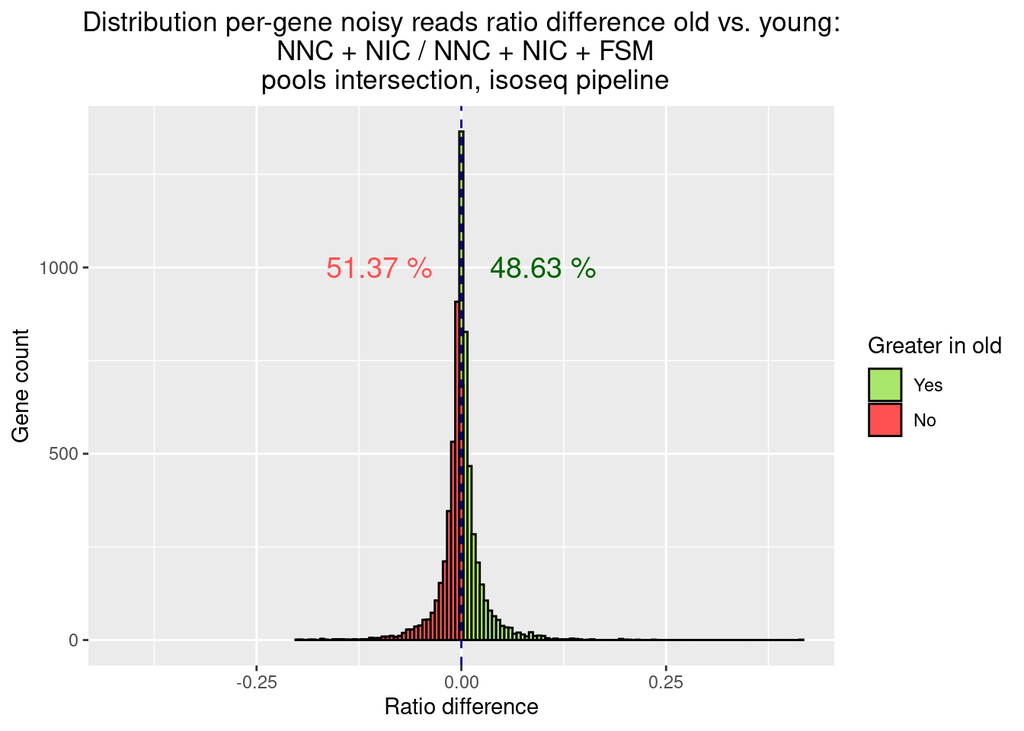

```r
# Function
RBN_histogram <- function(data) {
  # Filtramos los valores diferentes de 0
  data_filtrado <- data[complete.cases(data) & data$noisy_reads_ratio_diff != 0, ]

  # Calculamos el porcentaje de genes por encima y por debajo de 0
  genes_above_0 <- sum(data_filtrado[, "noisy_reads_ratio_diff"] > 0)
  genes_below_0 <- sum(data_filtrado[, "noisy_reads_ratio_diff"] < 0)
  total_genes <- nrow(data_filtrado)
  porcentaje_above_0 <- round((genes_above_0 / total_genes) * 100, 2)
  porcentaje_below_0 <- round((genes_below_0 / total_genes) * 100, 2)

  # Creamos el histograma
  histograma <- ggplot(data_filtrado, aes(x = data_filtrado[, "noisy_reads_ratio_diff"], fill = ifelse(data_filtrado[, "noisy_reads_ratio_diff"] > 0, "above_0", "below_0"))) +
    geom_histogram(binwidth = 0.005, color = "black") +
    geom_vline(xintercept = 0, color = "darkblue", linetype = "dashed") +
    labs(x = "Ratio difference", y = "Gene count", title = paste("Distribution per-gene noisy reads ratio difference old vs. young:\n", "NNC + NIC / NNC + NIC + FSM\n", "pools intersection, isoseq pipeline")) +
    scale_fill_manual(name = "Greater in old", values = c("above_0" = "#aae56c", "below_0" = "#ff5151"), labels = c("Yes", "No")) +
    coord_cartesian(xlim = c(-max(abs(data_filtrado[, "noisy_reads_ratio_diff"])), max(abs(data_filtrado[, "noisy_reads_ratio_diff"])))) +
    annotate("text", x = -0.1, y = 1000, label = paste(porcentaje_below_0, "%"), color = "#ff5151", size = 5) +
    annotate("text", x = 0.1, y = 1000, label = paste(porcentaje_above_0, "%"), color = "darkgreen", size = 5) +
    theme(plot.title = element_text(hjust = 0.5))

  return(histograma)
}
noisy_reads_ratio_difference <- read.table("/home/carblan/Documents/R_files/TFM/isoseq_FSM>=10_intersection_filtered_genes/per_gene_noisy_reads_ratio/noisy_reads_ratio_difference_per_gene.txt", header = TRUE)
histogram <- RBN_histogram(noisy_reads_ratio_difference)
print(histogram)
```

## 9.3 Intersection (only pool 1 counts)

```r
files <- list.files(path = "/home/carblan/Documents/R_files/TFM/isoseq_filtered_per_gene_classifications",
                    full.names = TRUE)
# Inicializar una lista para almacenar los datos filtrados
filtered_data <- list()

# Iterar sobre cada archivo
for (file in files) {
  # Leer el archivo
  data <- read.table(file, header=TRUE, stringsAsFactors=FALSE)

  # Filtrar los genes cuyo valor en la columna "full_splice_match_counts" es menor que 10
  data <- data[data$full_splice_match_counts >= 10,]

  # Almacenar los datos filtrados
  filtered_data[[file]] <- data
}

# Obtener la lista de genes que aparecen en todos los archivos con FSM>=10
associated_genes <- Reduce(intersect, lapply(filtered_data, function(x) x$associated_gene))

files <- list.files(path = "/home/carblan/Documents/R_files/TFM/isoseq_FSM>=10_intersection_filtered_genes/per_gene_structural_categories_ratios", pattern=".txt", full.names = TRUE)

young_files_pool1 <- files[str_detect(basename(files), "^B3[1-3]")]
old_files_pool1 <- files[str_detect(basename(files), "^B15[1-2]")]

# Función para calcular la media de los ratios por associated_gene y chrom
calculate_mean_ratios <- function(files) {
  # Leer los archivos y combinarlos en un solo dataframe
  data <- map_dfr(files, ~read.table(.x, header=TRUE, stringsAsFactors=FALSE))

  # Agrupar por associated_gene y chrom y calcular la media de los ratios de cada categoría estructural
  data_mean <- data %>%
    group_by(associated_gene, chrom) %>%
    summarise(across(starts_with("median_length"), mean),
            across(starts_with("median_exons"), mean),
            across(starts_with("full"), mean),
            across(starts_with("incomplete"), mean),
            across(starts_with("novel_not"), mean),
            across(starts_with("novel_in"), mean),
            across(starts_with("genic"), mean),
            total_counts = mean(total_counts),  # Calcular la media de la columna "total_counts"
            .groups = "drop") %>%
    arrange(associated_gene)  # Ordenar primero por chrom y luego por associated_gene

  return(data_mean)
}

# Calcular la media de los ratios para el grupo young
young_mean_ratios_pool1 <- calculate_mean_ratios(young_files_pool1)

# Calcular la media de los ratios para el grupo old
old_mean_ratios_pool1 <- calculate_mean_ratios(old_files_pool1)

# Función para calcular los "noisy reads ratios"
calculate_noisy_reads_ratios <- function(data) {
  # Calcular las métricas para cada fila
  noisy_reads_ratio <- (data$novel_in_catalog_counts + data$novel_not_in_catalog_counts) / (data$full_splice_match_counts + data$novel_in_catalog_counts + data$novel_not_in_catalog_counts)

  # Crear un nuevo dataframe con los resultados
  noisy_reads_ratios <- data.frame(
    associated_gene = data$associated_gene,
    chrom = data$chrom,
    average_length = data$median_length,
    average_exons = data$median_exons,
    noisy_reads_ratio = noisy_reads_ratio
  )

  return(noisy_reads_ratios)
}

# Calcular los "noisy reads ratios" para young y old
young_noisy_reads_ratios_pool1 <- calculate_noisy_reads_ratios(young_mean_ratios_pool1)
old_noisy_reads_ratios_pool1 <- calculate_noisy_reads_ratios(old_mean_ratios_pool1)


calculate_difference <- function(young_data, old_data) {
  # Combinar los dataframes por la columna associated_gene
  combined_data <- merge(old_data, young_data, by = "associated_gene", suffixes = c("_old", "_young"))

  # Calcular las diferencias para cada métrica
  noisy_reads_ratio_diff <- combined_data$noisy_reads_ratio_old - combined_data$noisy_reads_ratio_young

  # Calcular la media de average_length y average_exons para cada associated_gene
  media_average_length <- rowMeans(combined_data[, c("average_length_old", "average_length_young")], na.rm = TRUE)
  media_average_exons <- rowMeans(combined_data[, c("average_exons_old", "average_exons_young")], na.rm = TRUE)

  # Construir el dataframe noisy_reads_ratio_difference con las medias calculadas
  noisy_reads_ratio_difference <- data.frame(
    associated_gene = combined_data$associated_gene,
    chrom = combined_data$chrom_old,  # Puedes elegir la columna chrom de old_data o young_data
    average_length = media_average_length,
    average_exons = media_average_exons,
    noisy_reads_ratio_diff = noisy_reads_ratio_diff
  )

  return(noisy_reads_ratio_difference)
}

# Calcular las diferencias de noisy reads ratios
noisy_reads_ratio_difference_pool1 <- calculate_difference(young_noisy_reads_ratios_pool1, old_noisy_reads_ratios_pool1)
```

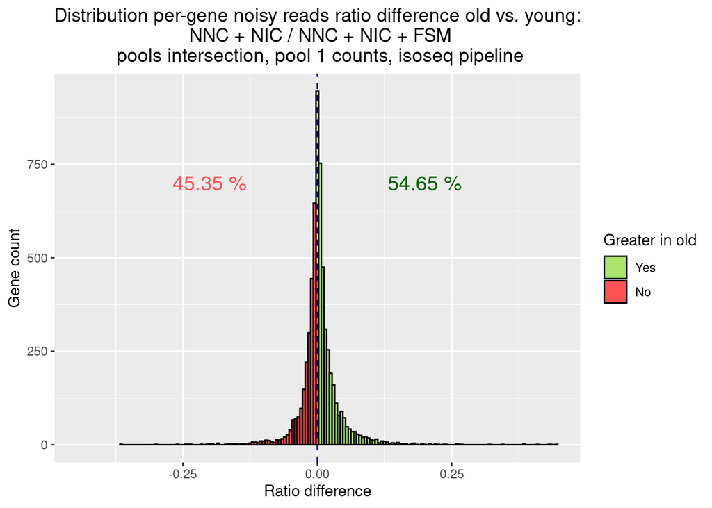

```r
# Function
RBN_histogram <- function(data) {
  # Filtramos los valores diferentes de 0
  data_filtrado <- data[complete.cases(data) & data$noisy_reads_ratio_diff != 0, ]

  # Calculamos el porcentaje de genes por encima y por debajo de 0
  genes_above_0 <- sum(data_filtrado[, "noisy_reads_ratio_diff"] > 0)
  genes_below_0 <- sum(data_filtrado[, "noisy_reads_ratio_diff"] < 0)
  total_genes <- nrow(data_filtrado)
  porcentaje_above_0 <- round((genes_above_0 / total_genes) * 100, 2)
  porcentaje_below_0 <- round((genes_below_0 / total_genes) * 100, 2)

  # Creamos el histograma
  histograma <- ggplot(data_filtrado, aes(x = data_filtrado[, "noisy_reads_ratio_diff"], fill = ifelse(data_filtrado[, "noisy_reads_ratio_diff"] > 0, "above_0", "below_0"))) +
    geom_histogram(binwidth = 0.005, color = "black") +
    geom_vline(xintercept = 0, color = "darkblue", linetype = "dashed") +
    labs(x = "Ratio difference", y = "Gene count", title = paste("Distribution per-gene noisy reads ratio difference old vs. young:\n", "NNC + NIC / NNC + NIC + FSM\n", "pools intersection, pool 1 counts, isoseq pipeline")) +
    scale_fill_manual(name = "Greater in old", values = c("above_0" = "#aae56c", "below_0" = "#ff5151"), labels = c("Yes", "No")) +
    coord_cartesian(xlim = c(-max(abs(data_filtrado[, "noisy_reads_ratio_diff"])), max(abs(data_filtrado[, "noisy_reads_ratio_diff"])))) +
    annotate("text", x = -0.2, y = 700, label = paste(porcentaje_below_0, "%"), color = "#ff5151", size = 5) +
    annotate("text", x = 0.2, y = 700, label = paste(porcentaje_above_0, "%"), color = "darkgreen", size = 5) +
    theme(plot.title = element_text(hjust = 0.5))

  return(histograma)
}
histogram <- RBN_histogram(noisy_reads_ratio_difference_pool1)
print(histogram)
```

## 9.4 Intersection (only pool 2 counts)

```r
files <- list.files(path = "/home/carblan/Documents/R_files/TFM/isoseq_filtered_per_gene_classifications",
                    full.names = TRUE)
# Inicializar una lista para almacenar los datos filtrados
filtered_data <- list()

# Iterar sobre cada archivo
for (file in files) {
  # Leer el archivo
  data <- read.table(file, header=TRUE, stringsAsFactors=FALSE)

  # Filtrar los genes cuyo valor en la columna "full_splice_match_counts" es menor que 10
  data <- data[data$full_splice_match_counts >= 10,]

  # Almacenar los datos filtrados
  filtered_data[[file]] <- data
}

# Obtener la lista de genes que aparecen en todos los archivos con FSM>=10
associated_genes <- Reduce(intersect, lapply(filtered_data, function(x) x$associated_gene))

files <- list.files(path = "/home/carblan/Documents/R_files/TFM/isoseq_FSM>=10_intersection_filtered_genes/per_gene_structural_categories_ratios", pattern=".txt", full.names = TRUE)

young_files_pool2 <- files[str_detect(basename(files), "^B3[4-5]")]
old_files_pool2 <- files[str_detect(basename(files), "^B15[3-4]")]

# Función para calcular la media de los ratios por associated_gene y chrom
calculate_mean_ratios <- function(files) {
  # Leer los archivos y combinarlos en un solo dataframe
  data <- map_dfr(files, ~read.table(.x, header=TRUE, stringsAsFactors=FALSE))

  # Agrupar por associated_gene y chrom y calcular la media de los ratios de cada categoría estructural
  data_mean <- data %>%
    group_by(associated_gene, chrom) %>%
    summarise(across(starts_with("median_length"), mean),
            across(starts_with("median_exons"), mean),
            across(starts_with("full"), mean),
            across(starts_with("incomplete"), mean),
            across(starts_with("novel_not"), mean),
            across(starts_with("novel_in"), mean),
            across(starts_with("genic"), mean),
            total_counts = mean(total_counts),  # Calcular la media de la columna "total_counts"
            .groups = "drop") %>%
    arrange(associated_gene)  # Ordenar primero por chrom y luego por associated_gene

  return(data_mean)
}

# Calcular la media de los ratios para el grupo young
young_mean_ratios_pool2 <- calculate_mean_ratios(young_files_pool2)

# Calcular la media de los ratios para el grupo old
old_mean_ratios_pool2 <- calculate_mean_ratios(old_files_pool2)

# Función para calcular los "noisy reads ratios"
calculate_noisy_reads_ratios <- function(data) {
  # Calcular las métricas para cada fila
  noisy_reads_ratio <- (data$novel_in_catalog_counts + data$novel_not_in_catalog_counts) / (data$full_splice_match_counts + data$novel_in_catalog_counts + data$novel_not_in_catalog_counts)

  # Crear un nuevo dataframe con los resultados
  noisy_reads_ratios <- data.frame(
    associated_gene = data$associated_gene,
    chrom = data$chrom,
    average_length = data$median_length,
    average_exons = data$median_exons,
    noisy_reads_ratio = noisy_reads_ratio
  )

  return(noisy_reads_ratios)
}

# Calcular los "noisy reads ratios" para young y old
young_noisy_reads_ratios_pool2 <- calculate_noisy_reads_ratios(young_mean_ratios_pool2)
old_noisy_reads_ratios_pool2 <- calculate_noisy_reads_ratios(old_mean_ratios_pool2)


calculate_difference <- function(young_data, old_data) {
  # Combinar los dataframes por la columna associated_gene
  combined_data <- merge(old_data, young_data, by = "associated_gene", suffixes = c("_old", "_young"))

  # Calcular las diferencias para cada métrica
  noisy_reads_ratio_diff <- combined_data$noisy_reads_ratio_old - combined_data$noisy_reads_ratio_young

  # Calcular la media de average_length y average_exons para cada associated_gene
  media_average_length <- rowMeans(combined_data[, c("average_length_old", "average_length_young")], na.rm = TRUE)
  media_average_exons <- rowMeans(combined_data[, c("average_exons_old", "average_exons_young")], na.rm = TRUE)

  # Construir el dataframe noisy_reads_ratio_difference con las medias calculadas
  noisy_reads_ratio_difference <- data.frame(
    associated_gene = combined_data$associated_gene,
    chrom = combined_data$chrom_old,  # Puedes elegir la columna chrom de old_data o young_data
    average_length = media_average_length,
    average_exons = media_average_exons,
    noisy_reads_ratio_diff = noisy_reads_ratio_diff
  )

  return(noisy_reads_ratio_difference)
}

# Calcular las diferencias de noisy reads ratios
noisy_reads_ratio_difference_pool2 <- calculate_difference(young_noisy_reads_ratios_pool2, old_noisy_reads_ratios_pool2)
```

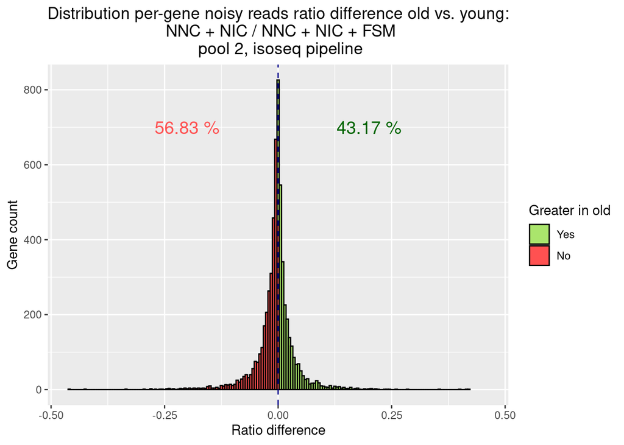

```r
# Function
RBN_histogram <- function(data) {
  # Filtramos los valores diferentes de 0
  data_filtrado <- data[complete.cases(data) & data$noisy_reads_ratio_diff != 0, ]

  # Calculamos el porcentaje de genes por encima y por debajo de 0
  genes_above_0 <- sum(data_filtrado[, "noisy_reads_ratio_diff"] > 0)
  genes_below_0 <- sum(data_filtrado[, "noisy_reads_ratio_diff"] < 0)
  total_genes <- nrow(data_filtrado)
  porcentaje_above_0 <- round((genes_above_0 / total_genes) * 100, 2)
  porcentaje_below_0 <- round((genes_below_0 / total_genes) * 100, 2)

  # Creamos el histograma
  histograma <- ggplot(data_filtrado, aes(x = data_filtrado[, "noisy_reads_ratio_diff"], fill = ifelse(data_filtrado[, "noisy_reads_ratio_diff"] > 0, "above_0", "below_0"))) +
    geom_histogram(binwidth = 0.005, color = "black") +
    geom_vline(xintercept = 0, color = "darkblue", linetype = "dashed") +
    labs(x = "Ratio difference", y = "Gene count", title = paste("Distribution per-gene noisy reads ratio difference old vs. young:\n", "NNC + NIC / NNC + NIC + FSM\n", "pool 2, isoseq pipeline")) +
    scale_fill_manual(name = "Greater in old", values = c("above_0" = "#aae56c", "below_0" = "#ff5151"), labels = c("Yes", "No")) +
    coord_cartesian(xlim = c(-max(abs(data_filtrado[, "noisy_reads_ratio_diff"])), max(abs(data_filtrado[, "noisy_reads_ratio_diff"])))) +
    annotate("text", x = -0.2, y = 700, label = paste(porcentaje_below_0, "%"), color = "#ff5151", size = 5) +
    annotate("text", x = 0.2, y = 700, label = paste(porcentaje_above_0, "%"), color = "darkgreen", size = 5) +
    theme(plot.title = element_text(hjust = 0.5))

  return(histograma)
}
histogram <- RBN_histogram(noisy_reads_ratio_difference_pool2)
print(histogram)
```

## 9.5 Pool 1 genes

```r
files <- list.files(path = "/home/carblan/Documents/R_files/TFM/isoseq_filtered_per_gene_classifications",
                    full.names = TRUE)
pool_1_files <- files[str_detect(basename(files), "^B3[1-3]|^B15[1-2]")]
# Inicializar una lista para almacenar los datos filtrados
filtered_data <- list()

# Iterar sobre cada archivo
for (file in pool_1_files) {
  # Leer el archivo
  data <- read.table(file, header=TRUE, stringsAsFactors=FALSE)

  # Filtrar los genes cuyo valor en la columna "full_splice_match_counts" es menor que 10
  data <- data[data$full_splice_match_counts >= 10,]

  # Almacenar los datos filtrados
  filtered_data[[file]] <- data
}

# Obtener la lista de genes que aparecen en todos los archivos de la pool 1 con FSM>=10
associated_genes <- Reduce(intersect, lapply(filtered_data, function(x) x$associated_gene))

# Crear un directorio para los archivos filtrados si no existe
dir <- "/home/carblan/Documents/R_files/TFM/isoseq_FSM>=10_pool_1_filtered_genes"
if (!dir.exists(dir)) {
  dir.create(dir)
}

# Iterar sobre cada archivo nuevamente para guardar los datos filtrados
for (file in pool_1_files) {
  # Filtrar los genes que aparecen en todos los archivos
  data <- filtered_data[[file]]
  data <- data[data$associated_gene %in% associated_genes,]

  # Guardar el archivo filtrado en la nueva ubicación
  write.table(data, file.path(dir, basename(file)), sep="\t", row.names=FALSE)
}

# Obtener la lista de archivos en el directorio actual
files <- list.files(path = "/home/carblan/Documents/R_files/TFM/isoseq_FSM>=10_pool_1_filtered_genes", pattern=".txt", full.names = TRUE)

# Crear el directorio para los archivos de salida si no existe
output_dir <- "/home/carblan/Documents/R_files/TFM/isoseq_FSM>=10_pool_1_filtered_genes/per_gene_structural_categories_ratios"
if (!dir.exists(output_dir)) {
  dir.create(output_dir, recursive = TRUE)
}

# Iterar sobre cada archivo
for (file in files) {
  # Leer el archivo
  data <- read.table(file, header=TRUE, stringsAsFactors=FALSE)

  # Calcular los ratios de cada categoría estructural para cada associated_gene
  categories <- colnames(data)[5:ncol(data)]
  for (category in categories) {
    data[[category]] <- data[[category]] / data$total_counts
  }

  # Guardar el archivo de salida
  output_file <- file.path(output_dir, basename(file))
  write.table(data, output_file, sep="\t", quote=FALSE, row.names=FALSE)
}

input_dir <- "/home/carblan/Documents/R_files/TFM/isoseq_FSM>=10_pool_1_filtered_genes/per_gene_structural_categories_ratios"

# Obtener la lista de archivos en el directorio
files <- list.files(path = input_dir, pattern=".txt", full.names = TRUE)

# Separar los archivos por grupo (young y old)
young_files <- files[str_detect(basename(files), "^B3[1-3]")]
old_files <- files[str_detect(basename(files), "^B15[1-2]")]

# Función para calcular la media de los ratios por associated_gene y chrom
calculate_mean_ratios <- function(files) {
  # Leer los archivos y combinarlos en un solo dataframe
  data <- map_dfr(files, ~read.table(.x, header=TRUE, stringsAsFactors=FALSE))

  # Agrupar por associated_gene y chrom y calcular la media de los ratios de cada categoría estructural
  data_mean <- data %>%
    group_by(associated_gene, chrom) %>%
    summarise(across(starts_with("median_length"), mean),
            across(starts_with("median_exons"), mean),
            across(starts_with("full"), mean),
            across(starts_with("incomplete"), mean),
            across(starts_with("novel_not"), mean),
            across(starts_with("novel_in"), mean),
            across(starts_with("genic"), mean),
            total_counts = mean(total_counts),  # Calcular la media de la columna "total_counts"
            .groups = "drop") %>%
    arrange(associated_gene)  # Ordenar primero por chrom y luego por associated_gene

  return(data_mean)
}

# Calcular la media de los ratios para el grupo young
young_mean_ratios <- calculate_mean_ratios(young_files)

# Calcular la media de los ratios para el grupo old
old_mean_ratios <- calculate_mean_ratios(old_files)

# Directorio donde se guardarán los archivos de salida
output_dir <- "/home/carblan/Documents/R_files/TFM/isoseq_FSM>=10_pool_1_filtered_genes/age_groups_per_gene_categories_mean_ratios"
if (!dir.exists(output_dir)) {
  dir.create(output_dir, recursive = TRUE)
}

# Guardar los resultados en archivos de salida
write.table(young_mean_ratios, file.path(output_dir, "young_mean_ratios.txt"), sep="\t", quote=FALSE, row.names=FALSE)
write.table(old_mean_ratios, file.path(output_dir, "old_mean_ratios.txt"), sep="\t", quote=FALSE, row.names=FALSE)

input_dir <- "/home/carblan/Documents/R_files/TFM/isoseq_FSM>=10_pool_1_filtered_genes/age_groups_per_gene_categories_mean_ratios"

# Leer los archivos de medias de los ratios para young y old
young_mean_ratios <- read.table(file.path(input_dir, "young_mean_ratios.txt"), header=TRUE, stringsAsFactors=FALSE)
old_mean_ratios <- read.table(file.path(input_dir, "old_mean_ratios.txt"), header=TRUE, stringsAsFactors=FALSE)

# Función para calcular los "noisy reads ratios"
calculate_noisy_reads_ratios <- function(data) {
  # Calcular las métricas para cada fila
  noisy_reads_ratio <- (data$novel_in_catalog_counts + data$novel_not_in_catalog_counts) / (data$full_splice_match_counts + data$novel_in_catalog_counts + data$novel_not_in_catalog_counts)

  # Crear un nuevo dataframe con los resultados
  noisy_reads_ratios <- data.frame(
    associated_gene = data$associated_gene,
    chrom = data$chrom,
    average_length = data$median_length,
    average_exons = data$median_exons,
    noisy_reads_ratio = noisy_reads_ratio
  )

  return(noisy_reads_ratios)
}

# Calcular los "noisy reads ratios" para young y old
young_noisy_reads_ratios <- calculate_noisy_reads_ratios(young_mean_ratios)
old_noisy_reads_ratios <- calculate_noisy_reads_ratios(old_mean_ratios)

# Directorio donde se guardarán los archivos de salida
output_dir <- "/home/carblan/Documents/R_files/TFM/isoseq_FSM>=10_pool_1_filtered_genes/per_gene_noisy_reads_ratio"
if (!dir.exists(output_dir)) {
  dir.create(output_dir)
}

# Guardar los resultados en archivos de salida
write.table(young_noisy_reads_ratios, file.path(output_dir, "young_noisy_reads_ratios.txt"), sep="\t", quote=FALSE, row.names=FALSE)
write.table(old_noisy_reads_ratios, file.path(output_dir, "old_noisy_reads_ratios.txt"), sep="\t", quote=FALSE, row.names=FALSE)

input_dir <- "/home/carblan/Documents/R_files/TFM/isoseq_FSM>=10_pool_1_filtered_genes/per_gene_noisy_reads_ratio"

# Leer los archivos de noisy reads ratios para young y old
young_noisy_reads_ratios <- read.table(file.path(input_dir, "young_noisy_reads_ratios.txt"), header=TRUE, stringsAsFactors=FALSE)
old_noisy_reads_ratios <- read.table(file.path(input_dir, "old_noisy_reads_ratios.txt"), header=TRUE, stringsAsFactors=FALSE)

calculate_difference <- function(young_data, old_data) {
  # Combinar los dataframes por la columna associated_gene
  combined_data <- merge(old_data, young_data, by = "associated_gene", suffixes = c("_old", "_young"))

  # Calcular las diferencias para cada métrica
  noisy_reads_ratio_diff <- combined_data$noisy_reads_ratio_old - combined_data$noisy_reads_ratio_young

  # Calcular la media de average_length y average_exons para cada associated_gene
  media_average_length <- rowMeans(combined_data[, c("average_length_old", "average_length_young")], na.rm = TRUE)
  media_average_exons <- rowMeans(combined_data[, c("average_exons_old", "average_exons_young")], na.rm = TRUE)

  # Construir el dataframe noisy_reads_ratio_difference con las medias calculadas
  noisy_reads_ratio_difference <- data.frame(
    associated_gene = combined_data$associated_gene,
    chrom = combined_data$chrom_old,  # Puedes elegir la columna chrom de old_data o young_data
    average_length = media_average_length,
    average_exons = media_average_exons,
    noisy_reads_ratio_diff = noisy_reads_ratio_diff
  )

  return(noisy_reads_ratio_difference)
}

# Calcular las diferencias de noisy reads ratios
noisy_reads_ratio_difference <- calculate_difference(young_noisy_reads_ratios, old_noisy_reads_ratios)

# Directorio donde se guardará el archivo de salida
output_dir <- "/home/carblan/Documents/R_files/TFM/isoseq_FSM>=10_pool_1_filtered_genes/per_gene_noisy_reads_ratio"
if (!dir.exists(output_dir)) {
  dir.create(output_dir)
}

# Guardar los resultados en un archivo de salida
write.table(noisy_reads_ratio_difference, file.path(output_dir, "noisy_reads_ratio_difference_per_gene.txt"), sep="\t", quote=FALSE, row.names=FALSE)
```

[figure not shown]

```r
data <- read.table("/home/carblan/Documents/R_files/TFM/isoseq_FSM>=10_pool_1_filtered_genes/per_gene_noisy_reads_ratio/noisy_reads_ratio_difference_per_gene.txt", header = TRUE)
histogram <- RBN_histogram(data)
print(histogram)
```

## 9.6 Pool 2 genes

```r
# Obtener la lista de archivos en el directorio actual
files <- list.files(path = "/home/carblan/Documents/R_files/TFM/isoseq_filtered_per_gene_classifications",
                    full.names = TRUE)
pool_2_files <- files[str_detect(basename(files), "^B3[4-5]|^B15[3-4]")]
# Inicializar una lista para almacenar los datos filtrados
filtered_data <- list()

# Iterar sobre cada archivo
for (file in pool_2_files) {
  # Leer el archivo
  data <- read.table(file, header=TRUE, stringsAsFactors=FALSE)

  # Filtrar los genes cuyo valor en la columna "full_splice_match_counts" es menor que 10
  data <- data[data$full_splice_match_counts >= 10,]

  # Almacenar los datos filtrados
  filtered_data[[file]] <- data
}

# Obtener la lista de genes que aparecen en todos los archivos de la pool 1 con FSM>=10
associated_genes <- Reduce(intersect, lapply(filtered_data, function(x) x$associated_gene))

# Crear un directorio para los archivos filtrados si no existe
dir <- "/home/carblan/Documents/R_files/TFM/isoseq_FSM>=10_pool_2_filtered_genes"
if (!dir.exists(dir)) {
  dir.create(dir)
}

# Iterar sobre cada archivo nuevamente para guardar los datos filtrados
for (file in pool_2_files) {
  # Filtrar los genes que aparecen en todos los archivos
  data <- filtered_data[[file]]
  data <- data[data$associated_gene %in% associated_genes,]

  # Guardar el archivo filtrado en la nueva ubicación
  write.table(data, file.path(dir, basename(file)), sep="\t", row.names=FALSE)
}

# Obtener la lista de archivos en el directorio actual
files <- list.files(path = "/home/carblan/Documents/R_files/TFM/isoseq_FSM>=10_pool_2_filtered_genes", pattern=".txt", full.names = TRUE)

# Crear el directorio para los archivos de salida si no existe
output_dir <- "/home/carblan/Documents/R_files/TFM/isoseq_FSM>=10_pool_2_filtered_genes/per_gene_structural_categories_ratios"
if (!dir.exists(output_dir)) {
  dir.create(output_dir, recursive = TRUE)
}

# Iterar sobre cada archivo
for (file in files) {
  # Leer el archivo
  data <- read.table(file, header=TRUE, stringsAsFactors=FALSE)

  # Calcular los ratios de cada categoría estructural para cada associated_gene
  categories <- colnames(data)[5:ncol(data)]
  for (category in categories) {
    data[[category]] <- data[[category]] / data$total_counts
  }

  # Guardar el archivo de salida
  output_file <- file.path(output_dir, basename(file))
  write.table(data, output_file, sep="\t", quote=FALSE, row.names=FALSE)
}

input_dir <- "/home/carblan/Documents/R_files/TFM/isoseq_FSM>=10_pool_2_filtered_genes/per_gene_structural_categories_ratios"

# Obtener la lista de archivos en el directorio
files <- list.files(path = input_dir, pattern=".txt", full.names = TRUE)

# Separar los archivos por grupo (young y old)
young_files <- files[str_detect(basename(files), "^B3[1-5]")]
old_files <- files[str_detect(basename(files), "^B15[1-4]")]

# Función para calcular la media de los ratios por associated_gene y chrom
calculate_mean_ratios <- function(files) {
  # Leer los archivos y combinarlos en un solo dataframe
  data <- map_dfr(files, ~read.table(.x, header=TRUE, stringsAsFactors=FALSE))

  # Agrupar por associated_gene y chrom y calcular la media de los ratios de cada categoría estructural
  data_mean <- data %>%
    group_by(associated_gene, chrom) %>%
    summarise(across(starts_with("median_length"), mean),
            across(starts_with("median_exons"), mean),
            across(starts_with("full"), mean),
            across(starts_with("incomplete"), mean),
            across(starts_with("novel_not"), mean),
            across(starts_with("novel_in"), mean),
            across(starts_with("genic"), mean),
            total_counts = mean(total_counts),  # Calcular la media de la columna "total_counts"
            .groups = "drop") %>%
    arrange(associated_gene)  # Ordenar primero por chrom y luego por associated_gene

  return(data_mean)
}

# Calcular la media de los ratios para el grupo young
young_mean_ratios <- calculate_mean_ratios(young_files)

# Calcular la media de los ratios para el grupo old
old_mean_ratios <- calculate_mean_ratios(old_files)

# Directorio donde se guardarán los archivos de salida
output_dir <- "/home/carblan/Documents/R_files/TFM/isoseq_FSM>=10_pool_2_filtered_genes/age_groups_per_gene_categories_mean_ratios"
if (!dir.exists(output_dir)) {
  dir.create(output_dir, recursive = TRUE)
}

# Guardar los resultados en archivos de salida
write.table(young_mean_ratios, file.path(output_dir, "young_mean_ratios.txt"), sep="\t", quote=FALSE, row.names=FALSE)
write.table(old_mean_ratios, file.path(output_dir, "old_mean_ratios.txt"), sep="\t", quote=FALSE, row.names=FALSE)

input_dir <- "/home/carblan/Documents/R_files/TFM/isoseq_FSM>=10_pool_2_filtered_genes/age_groups_per_gene_categories_mean_ratios"

# Leer los archivos de medias de los ratios para young y old
young_mean_ratios <- read.table(file.path(input_dir, "young_mean_ratios.txt"), header=TRUE, stringsAsFactors=FALSE)
old_mean_ratios <- read.table(file.path(input_dir, "old_mean_ratios.txt"), header=TRUE, stringsAsFactors=FALSE)

# Función para calcular los "noisy reads ratios"
calculate_noisy_reads_ratios <- function(data) {
  # Calcular las métricas para cada fila
  noisy_reads_ratio <- (data$novel_in_catalog_counts + data$novel_not_in_catalog_counts) / (data$full_splice_match_counts + data$novel_in_catalog_counts + data$novel_not_in_catalog_counts)

  # Crear un nuevo dataframe con los resultados
  noisy_reads_ratios <- data.frame(
    associated_gene = data$associated_gene,
    chrom = data$chrom,
    average_length = data$median_length,
    average_exons = data$median_exons,
    noisy_reads_ratio = noisy_reads_ratio
  )

  return(noisy_reads_ratios)
}

# Calcular los "noisy reads ratios" para young y old
young_noisy_reads_ratios <- calculate_noisy_reads_ratios(young_mean_ratios)
old_noisy_reads_ratios <- calculate_noisy_reads_ratios(old_mean_ratios)

# Directorio donde se guardarán los archivos de salida
output_dir <- "/home/carblan/Documents/R_files/TFM/isoseq_FSM>=10_pool_2_filtered_genes/per_gene_noisy_reads_ratio"
if (!dir.exists(output_dir)) {
  dir.create(output_dir)
}

# Guardar los resultados en archivos de salida
write.table(young_noisy_reads_ratios, file.path(output_dir, "young_noisy_reads_ratios.txt"), sep="\t", quote=FALSE, row.names=FALSE)
write.table(old_noisy_reads_ratios, file.path(output_dir, "old_noisy_reads_ratios.txt"), sep="\t", quote=FALSE, row.names=FALSE)

input_dir <- "/home/carblan/Documents/R_files/TFM/isoseq_FSM>=10_pool_2_filtered_genes/per_gene_noisy_reads_ratio"

# Leer los archivos de noisy reads ratios para young y old
young_noisy_reads_ratios <- read.table(file.path(input_dir, "young_noisy_reads_ratios.txt"), header=TRUE, stringsAsFactors=FALSE)
old_noisy_reads_ratios <- read.table(file.path(input_dir, "old_noisy_reads_ratios.txt"), header=TRUE, stringsAsFactors=FALSE)

calculate_difference <- function(young_data, old_data) {
  # Combinar los dataframes por la columna associated_gene
  combined_data <- merge(old_data, young_data, by = "associated_gene", suffixes = c("_old", "_young"))

  # Calcular las diferencias para cada métrica
  noisy_reads_ratio_diff <- combined_data$noisy_reads_ratio_old - combined_data$noisy_reads_ratio_young

  # Calcular la media de average_length y average_exons para cada associated_gene
  media_average_length <- rowMeans(combined_data[, c("average_length_old", "average_length_young")], na.rm = TRUE)
  media_average_exons <- rowMeans(combined_data[, c("average_exons_old", "average_exons_young")], na.rm = TRUE)

  # Construir el dataframe noisy_reads_ratio_difference con las medias calculadas
  noisy_reads_ratio_difference <- data.frame(
    associated_gene = combined_data$associated_gene,
    chrom = combined_data$chrom_old,  # Puedes elegir la columna chrom de old_data o young_data
    average_length = media_average_length,
    average_exons = media_average_exons,
    noisy_reads_ratio_diff = noisy_reads_ratio_diff
  )

  return(noisy_reads_ratio_difference)
}

# Calcular las diferencias de noisy reads ratios
noisy_reads_ratio_difference <- calculate_difference(young_noisy_reads_ratios, old_noisy_reads_ratios)

# Directorio donde se guardará el archivo de salida
output_dir <- "/home/carblan/Documents/R_files/TFM/isoseq_FSM>=10_pool_2_filtered_genes/per_gene_noisy_reads_ratio"
if (!dir.exists(output_dir)) {
  dir.create(output_dir)
}

# Guardar los resultados en un archivo de salida
write.table(noisy_reads_ratio_difference, file.path(output_dir, "noisy_reads_ratio_difference_per_gene.txt"), sep="\t", quote=FALSE, row.names=FALSE)
```

```r
# Function
RBN_histogram <- function(data) {
  # Filtramos los valores diferentes de 0
  data_filtrado <- data[complete.cases(data) & data$noisy_reads_ratio_diff != 0, ]

  # Calculamos el porcentaje de genes por encima y por debajo de 0
  genes_above_0 <- sum(data_filtrado[, "noisy_reads_ratio_diff"] > 0)
  genes_below_0 <- sum(data_filtrado[, "noisy_reads_ratio_diff"] < 0)
  total_genes <- nrow(data_filtrado)
  porcentaje_above_0 <- round((genes_above_0 / total_genes) * 100, 2)
  porcentaje_below_0 <- round((genes_below_0 / total_genes) * 100, 2)

  # Creamos el histograma
  histograma <- ggplot(data_filtrado, aes(x = data_filtrado[, "noisy_reads_ratio_diff"], fill = ifelse(data_filtrado[, "noisy_reads_ratio_diff"] > 0, "above_0", "below_0"))) +
    geom_histogram(binwidth = 0.01, color = "black") +
    geom_vline(xintercept = 0, color = "darkblue", linetype = "dashed") +
    labs(x = "Ratio difference", y = "Gene count", title = paste("Distribution per-gene noisy reads ratio difference old vs. young:\n", "NNC + NIC / NNC + NIC + FSM")) +
    scale_fill_manual(name = "Greater in old", values = c("above_0" = "#aae56c", "below_0" = "#ff5151"), labels = c("Yes", "No")) +
    coord_cartesian(xlim = c(-max(abs(data_filtrado[, "noisy_reads_ratio_diff"])), max(abs(data_filtrado[, "noisy_reads_ratio_diff"])))) +
    annotate("text", x = -0.25, y = 1250, label = paste(porcentaje_below_0, "%"), color = "#ff5151", size = 5) +
    annotate("text", x = 0.25, y = 1250, label = paste(porcentaje_above_0, "%"), color = "darkgreen", size = 5) +
    theme(plot.title = element_text(hjust = 0.5))

  return(histograma)
}
```

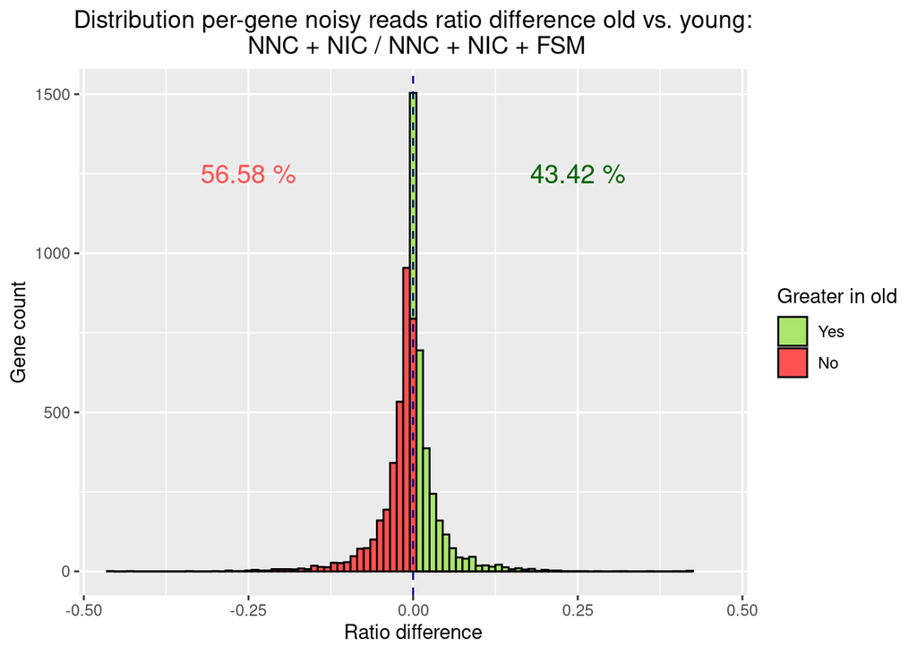

```r
data <- read.table("/home/carblan/Documents/R_files/TFM/isoseq_FSM>=10_pool_2_filtered_genes/per_gene_noisy_reads_ratio/noisy_reads_ratio_difference_per_gene.txt", header = TRUE)
histogram <- RBN_histogram(data)
print(histogram)
```